# COVID 19 Analysis by AJP

28Oct2025

#### Required Packages

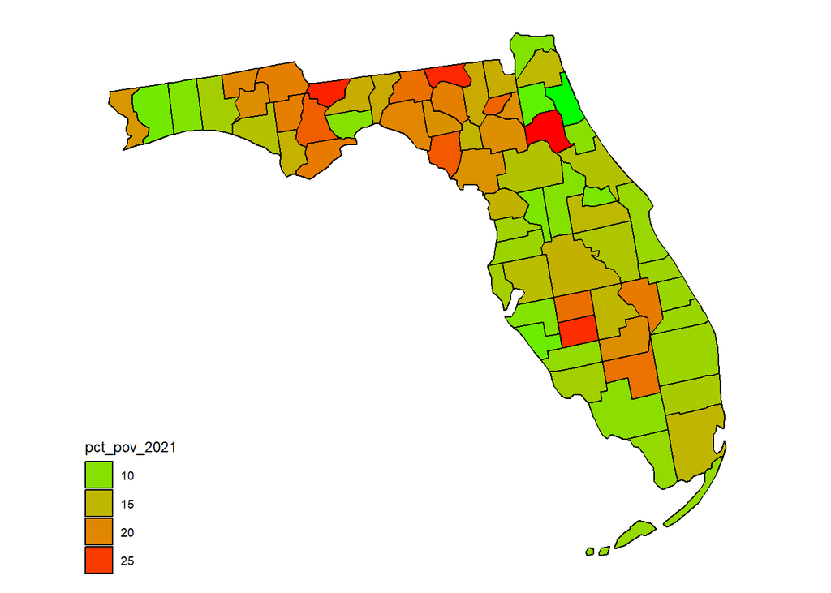

```r
fl <- plot_usmap("counties", data = countypov, values = "pct_pov_2021", include = "FL", data_year = 2021) +
  scale_fill_continuous(low = "green", high = "red", guide = "legend")

fl
```

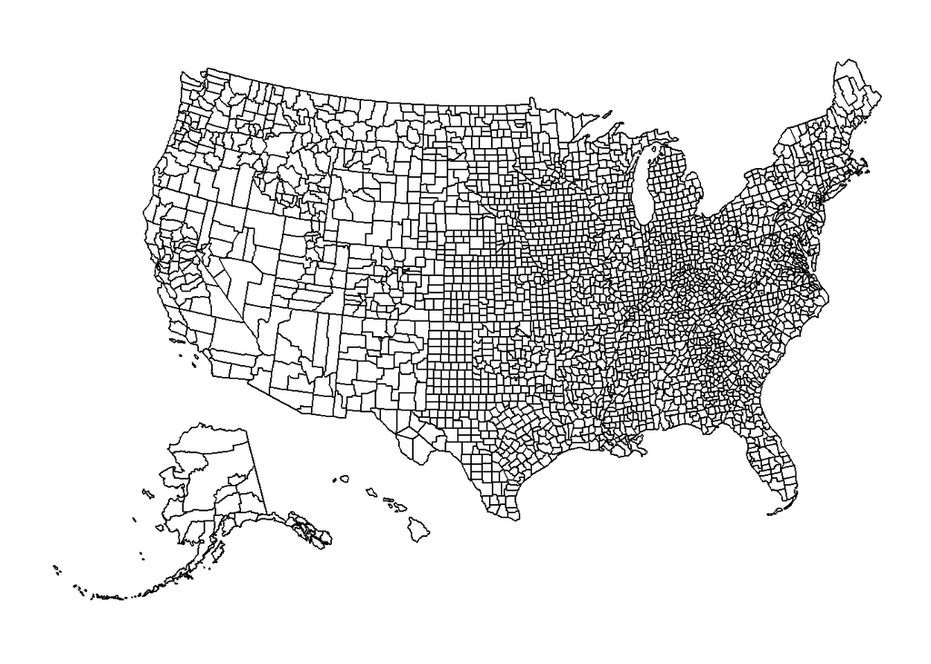

```r
counties <- plot_usmap("counties")

counties
```

#### Part 1 - Basic Exploration of US Data

#NYT GITHUB SOURCE: https://github.com/nytimes/covid-19-data?tab=readme-ov-file

#cases and deaths are CUMULATIVE values!!! to find “new” cases, one must subtract the current day with the previous day!

#The New York Times (the Times) has aggregated reported COVID-19 data from state and local governments and health departments since 2020 and provides public access through a repository on GitHub. One of the data sets provided by the Times is county-level data for cumulative cases and deaths each day. This will be your primary data set for the first two parts of your analysis.

#County-level COVID data from 2020, 2021, and 2022 (2023 added by AJP) has been imported below. Each row of data reports the cumulative number of cases and deaths for a specific county each day. A FIPS code, a standard geographic identifier, is also provided which you will use in Part 2 to construct a map visualization at the county level for a state.

#Additionally, county-level population estimates reported by the US Census Bureau has been imported as well. You will use these estimates to caluclate statistics per 100,000 people.

```r
# Import New York Times COVID-19 data
# Import Population Estimates from US Census Bureau

us_counties_2020 <- read_csv("https://raw.githubusercontent.com/nytimes/covid-19-data/master/us-counties-2020.csv")
us_counties_2021 <- read_csv("https://raw.githubusercontent.com/nytimes/covid-19-data/master/us-counties-2021.csv")
us_counties_2022 <- read_csv("https://raw.githubusercontent.com/nytimes/covid-19-data/master/us-counties-2022.csv")
us_population_estimates <- read_csv("data/fips_population_estimates.csv")
```

```r
COVIDurls <- c("https://github.com/nytimes/covid-19-data/raw/refs/heads/master/us-counties-2020.csv",
               "https://github.com/nytimes/covid-19-data/raw/refs/heads/master/us-counties-2021.csv",
               "https://github.com/nytimes/covid-19-data/raw/refs/heads/master/us-counties-2022.csv",
               "https://github.com/nytimes/covid-19-data/raw/refs/heads/master/us-counties-2023.csv"
) #I still need the data from the CSSE

COVID <- COVIDurls %>% #name a tibble and call the CSV list
  map(read_csv) %>% #read the list of CSVs
  list_rbind() %>% #binding the tables together
  drop_na() %>% #remove any row that has at least 1 NA
  filter(state != "Puerto Rico") %>% # remove Puerto Rico from the analysis as instructed
  arrange((date))
head(COVID) # view some of the table
```

| date | county | state | fips | cases | deaths |
| --- | --- | --- | --- | --- | --- |
| 2020-01-21 | Snohomish | Washington | 53061 | 1 | 0 |
| 2020-01-22 | Snohomish | Washington | 53061 | 1 | 0 |
| 2020-01-23 | Snohomish | Washington | 53061 | 1 | 0 |
| 2020-01-24 | Cook | Illinois | 17031 | 1 | 0 |
| 2020-01-24 | Snohomish | Washington | 53061 | 1 | 0 |
| 2020-01-25 | Orange | California | 06059 | 1 | 0 |

```r
# Check for mixed types (e.g., if a numeric column unexpectedly has a 'character' type)
# Check for unrealistic range in numeric columns that might signal mixed units

COVID %>%
  summarise(across(where(is.numeric), list(min = min, max = max, mean = mean), .names = "{.col}_{.fn}"))
```

| cases_min | cases_max | cases_mean | deaths_min | deaths_max | deaths_mean |
| --- | --- | --- | --- | --- | --- |
| 1 | 3723182 | 15473.33 | 0 | 35960 | 201.2858 |

```r
# death column is NA, likely a non-number is buried


#double check the column data type
print(class(COVID$deaths)) # result is numeric
```

```
## [1] "numeric"
```

```r
#if the column is NOT dbl or numeric use non_numeric_deaths
#filter out the numbers to view the characters
non_numeric_deaths <- COVID %>%
  filter(grepl("[^0-9.-]", deaths)) %>%
  pull(deaths) %>%
  unique()
non_numeric_deaths #this  yields "numeric(0)"
```

```
## numeric(0)
```

```r
#if the column is dbl or numeric
row_deaths_na <- COVID %>%
  filter(is.na(deaths)) %>%
  select(date, county, deaths)
print(row_deaths_na, n = 10) # 82097 NAs in <deaths> now 0
```

```
## # A tibble: 0 × 3
## # ℹ 3 variables: date <date>, county <chr>, deaths <dbl>
```

```r
row_cases_na <- COVID %>%
  filter(is.na(cases)) %>%
  select(date, county, cases)
print(row_cases_na, n = 10) # was unk NAs in <cases>, now 0
```

```
## # A tibble: 0 × 3
## # ℹ 3 variables: date <date>, county <chr>, cases <dbl>
```

##### Question 1

# Your first task is to combine and tidy the 2020, 2021, and 2022 COVID data sets and find the total deaths and cases for each day since March 15, 2020 (2020-03-15). The data sets provided #from the NY Times also includes statistics from Puerto Rico, a US territory. You may remove these observations from the data as they will not be needed for your analysis.

# a) tidy the data @Line 89

# b) find the total COVID-19 cases and deaths since March 15, 2020 @Line 143

# c) Write a sentence or two after the code block communicating your results. @Line 158-159

# d) Use inline code to include the #`max_date`, `us_total_cases`, and `us_total_deaths` variables. To write inline code use `r`. @Line 158-159

```r
latest_cumulative_data <- COVID %>% # filter for the latest record for each county.
      arrange((date), state, county) %>% # Ensure the date is sorted ascending within each group
      group_by(state, county) %>% # Group the data by County and State
      slice_tail(n = 1)  %>%   # Slice the last row in each group, which corresponds to the latest date
                            # Because the data is sorted by date, the last row is the max cumulative value.
      ungroup()

((latest_cumulative_data)) # inspect the latest records
```

| date | county | state | fips | cases | deaths |
| --- | --- | --- | --- | --- | --- |
| 2023-03-23 | Autauga | Alabama | 01001 | 19812 | 235 |
| 2023-03-23 | Baldwin | Alabama | 01003 | 70040 | 730 |
| 2023-03-23 | Barbour | Alabama | 01005 | 7509 | 113 |
| 2023-03-23 | Bibb | Alabama | 01007 | 8105 | 111 |
| 2023-03-23 | Blount | Alabama | 01009 | 18747 | 261 |
| 2023-03-23 | Bullock | Alabama | 01011 | 3042 | 54 |
| 2023-03-23 | Butler | Alabama | 01013 | 6568 | 132 |
| 2023-03-23 | Calhoun | Alabama | 01015 | 41502 | 683 |
| 2023-03-23 | Chambers | Alabama | 01017 | 10890 | 181 |
| 2023-03-23 | Cherokee | Alabama | 01019 | 6772 | 135 |

[output cut: 3132 more lines]

```r
us_total_cases <- latest_cumulative_data %>% #needs upgroup() in latest_cumulative_data to work
  summarise( # use summarise to do maths
        us_total_cases = sum(cases, na.rm = TRUE),  # Sum the latest 'cases' values across all counties/states
        )

us_total_deaths <- latest_cumulative_data %>% #needs upgroup() in latest_cumulative_data to work
  summarise( # use summarise to do maths
    us_total_deaths = sum(deaths, na.rm = TRUE) # Sum the latest 'deaths' values across all counties/states
  )
print(us_total_cases)
```

```
## # A tibble: 1 × 1
##   us_total_cases
##            <dbl>
## 1       98906469
```

```r
print(us_total_deaths) # Display the final result
```

```
## # A tibble: 1 × 1
##   us_total_deaths
##             <dbl>
## 1         1077824
```

### Data Report p1q1

The total number deaths attributable to COVID-19 in the USA was

| us_total_deaths |
| --- |
| 1077824 |

. The total number of cases or suspected cases of COVID-19 in the USA was

| us_total_cases |
| --- |
| 98906469 |

.

```r
# Combine and tidy the 2020, 2021, and 2022 COVID data sets. 2023 added too

# a) Tidiness was achieved above while NAs were removed during the join processing, see line 56 above

## YOUR CODE HERE _ AJP ##

daily_totals <- COVID %>% # replace the quotes with your code to find the most recent date in the data set
  filter(date >= "2020-03-15" ) %>%
  group_by(date) %>%
  summarise(
    cum_daily_cases = sum(cases, na.rm = TRUE),
    cum_daily_deaths = sum(deaths, na.rm = TRUE)
  ) %>%
  ungroup()

head(daily_totals, 10)
```

| date | cum_daily_cases | cum_daily_deaths |
| --- | --- | --- |
| 2020-03-15 | 3240 | 63 |
| 2020-03-16 | 4009 | 84 |
| 2020-03-17 | 5222 | 106 |
| 2020-03-18 | 6947 | 137 |
| 2020-03-19 | 9824 | 181 |
| 2020-03-20 | 13434 | 223 |
| 2020-03-21 | 17918 | 284 |
| 2020-03-22 | 23448 | 335 |
| 2020-03-23 | 30082 | 419 |
| 2020-03-24 | 37696 | 535 |

```r
# Your output should look similar to the following tibble:
#
#   A tibble: 657 x 3
#       date          total_deaths   total_cases
#      <date>            <dbl>         <dbl>
#   1 2020-03-15           68          3595
#   2 2020-03-16           91          4502
#   3 2020-03-17          117          5901
#   4 2020-03-18          162          8345
#   5 2020-03-19          212         12387
#   6 2020-03-20          277         17998
#   7 2020-03-21          359         24507
#   8 2020-03-22          457         33050
#   9 2020-03-23          577         43474
#  10 2020-03-24          783         53899
# ... with 647 more rows
#
```

– Communicate your methodology, results, and interpretation here – As of November 11, 2025, the data has been ‘archived’ and has not been updated in months. Because the cases and deaths data are cumulative, the newest entry is the ‘final’ cumulative total count of cases or deaths. I filtered and chose the final row of every local’s (county, state) entry and sum those values for the

| us_total_deaths |
| --- |
| 1077824 |

and

| us_total_cases |
| --- |
| 98906469 |

. “max_date” is not covered here.

##### Question 2

#Create a visualization for the total number of deaths and cases in the US since March 15, 2020. Before you create your visualization, review the types of plots you can create using the ggplot2 library and think about which plots would be effective in communicating your results. After you have created your visualization, write a few sentences describing your visualization. How could the plot be interpreted? Could it be misleading?

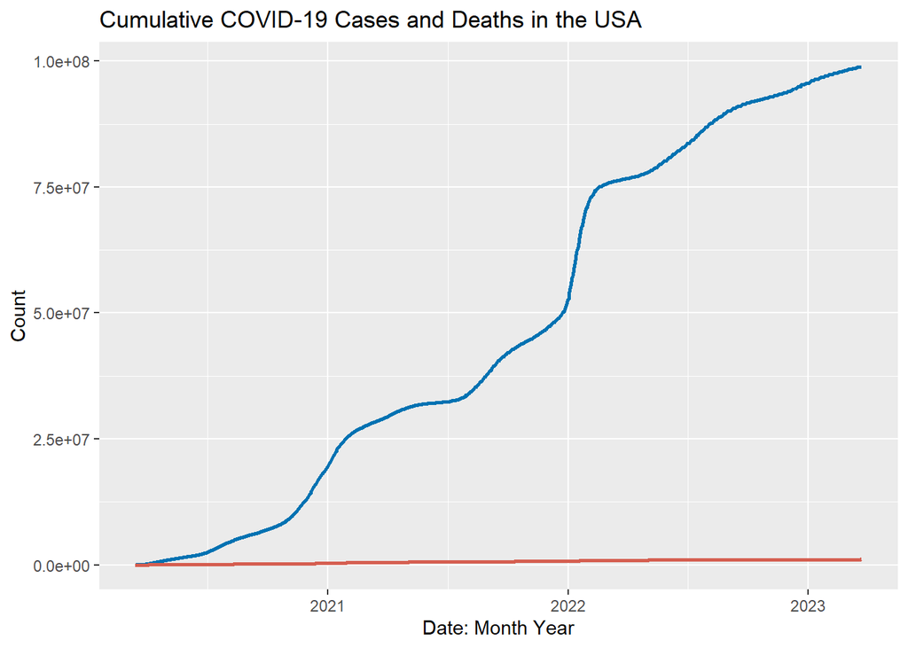

```r
cum_daily_vis <-  daily_totals %>%
  ggplot(aes(x = date)) +
  geom_line(aes(y = (cum_daily_cases)), color = "#0072B2", linewidth = 1) +
  geom_line(aes(y = (cum_daily_deaths)), color = "#D55E50", linewidth = 1) +
  labs(title = "Cumulative COVID-19 Cases and Deaths in the USA",
       y = "Count",
       x = "Date: Month Year")

cum_daily_vis
```

– Communicate your methodology, results, and interpretation here – A line graph is a good way to show changes over time. Here, I represent cumulative deaths in red and cases in blue. Notice the upward trend in both (this is because the data is cumulative). Deaths were about 1% of cases at the end of documentation.

##### Question 3

#While it is important to know the total deaths and cases throughout the COVID-19 pandemic, it is also important for local and state health officials to know the the number of new cases and deaths each day to understand how rapidly the virus is spreading. Using the table you created in Question 1… #calculate the number of new deaths and cases each day @Block 222 #caluclate the seven-day average of new deaths and cases. Once you have organized your data, @block 222 #find the days that saw the largest number of new cases and deaths. @Block 238. #Write a sentence or two after the code block communicating your results.

```r
totals_daily_1_7 <- daily_totals %>% #label a new tibble for the objective
  arrange(date >= "2020-03-15") %>% #grab the columns of interest
  mutate( #make a new column with the difference in cases using lag()
    delta_cases_1 = cum_daily_cases - lag(cum_daily_cases, n = 1),
    delta_deaths_1 = cum_daily_deaths - lag(cum_daily_deaths, n = 1),
    delta_cases_7 = (cum_daily_cases - lag(cum_daily_cases, n = 7))/7, #divide calc by 7 to get the average over 7 days
    delta_deaths_7 = (cum_daily_deaths - lag(cum_daily_deaths, n = 7))/7, #divide calc by 7 to get the average over 7 days
    )

totals_daily_1_7
```

| date | cum_daily_cases | cum_daily_deaths | delta_cases_1 | delta_deaths_1 | delta_cases_7 | delta_deaths_7 |
| --- | --- | --- | --- | --- | --- | --- |
| 2020-03-15 | 3240 | 63 | NA | NA | NA | NA |
| 2020-03-16 | 4009 | 84 | 769 | 21 | NA | NA |
| 2020-03-17 | 5222 | 106 | 1213 | 22 | NA | NA |
| 2020-03-18 | 6947 | 137 | 1725 | 31 | NA | NA |
| 2020-03-19 | 9824 | 181 | 2877 | 44 | NA | NA |
| 2020-03-20 | 13434 | 223 | 3610 | 42 | NA | NA |
| 2020-03-21 | 17918 | 284 | 4484 | 61 | NA | NA |
| 2020-03-22 | 23448 | 335 | 5530 | 51 | 2886.857 | 38.85714 |
| 2020-03-23 | 30082 | 419 | 6634 | 84 | 3724.714 | 47.85714 |
| 2020-03-24 | 37696 | 535 | 7614 | 116 | 4639.143 | 61.28571 |

[output cut: 1094 more lines]

```r
# Create a new table, based on the table from Question 1, and calculate the number of new deaths and cases each day and a seven day average of new deaths and cases.
#
# Hint: Look at the documentation for lag() when computing the number of new deaths and cases and the seven-day averages.
#
#
## YOUR CODE HERE ##

#  date > (max_new_cases_date and max_new_deaths_date)
#  total_deaths     >  the cumulative number of deaths up to and including the associated date
#  total_cases      >  the cumulative number of cases up to and including the associated date
#  delta_deaths_1   >  the number of new deaths since the previous day
#  delta_cases_1    >  the number of new cases since the previous day
#  delta_deaths_7   >  the average number of deaths in a seven-day period
#  delta_cases_7    >  the average number of cases in a seven-day period

max_new_cases_date <- daily_totals %>% #label a new tibble for the objective
  arrange(date) %>% #grab the columns of interest
  mutate( #make a new column with the difference in cases using lag()
    new_cases = cum_daily_cases - lag(cum_daily_cases, n = 1)) %>%
  filter(!is.na(new_cases)) %>%
    slice_max(order_by = new_cases, n = 1) %>%
  select(max_new_cases_date = date)

max_new_cases_date
```

| max_new_cases_date |
| --- |
| 2022-01-14 |

```r
max_new_deaths_date <- daily_totals %>%
  mutate(
    new_deaths = cum_daily_deaths - lag(cum_daily_deaths, n = 1)
  ) %>%
  filter(!is.na(new_deaths)) %>%
  slice_max(order_by = new_deaths, n = 1) %>%
  select(max_new_deaths_date = date)

max_new_deaths_date
```

| max_new_deaths_date |
| --- |
| 2021-09-14 |

| max_new_cases_date |
| --- |
| 2022-01-14 |

and

| max_new_deaths_date |
| --- |
| 2021-09-14 |

.

```r
#  Your output should look similar to the following tibble:
#
#  date
#  total_deaths     >  the cumulative number of deaths up to and including the associated date
#  total_cases      >  the cumulative number of cases up to and including the associated date
#  delta_deaths_1   >  the number of new deaths since the previous day
#  delta_cases_1    >  the number of new cases since the previous day
#  delta_deaths_7   >  the average number of deaths in a seven-day period
#  delta_cases_7    >  the average number of cases in a seven-day period
#==
#  A tibble: 813 x 7
#    date           total_deaths   total_cases   delta_deaths_1    delta_cases_1  delta_deaths_7  delta_cases_7
#    <date>            <dbl>          <dbl>         <dbl>               <dbl>        <dbl>            <dbl>
#  1 2020-03-15           68          3600            0                     0         NA                NA
#  2 2020-03-16           91          4507           23                   907         NA                NA
#  3 2020-03-17          117          5906           26                  1399         NA                NA
#  4 2020-03-18          162          8350           45                  2444         NA                NA
#  5 2020-03-19          212         12393           50                  4043         NA                NA
#  6 2020-03-20          277         18012           65                  5619         NA                NA
#  7 2020-03-21          360         24528           83                  6516         NA                NA
#  8 2020-03-22          458         33073           98                  8545       55.7              4210.
#  9 2020-03-23          579         43505          121                 10432       69.7              5571.
# 10 2020-03-24          785         53938          206                 10433       95.4              6862.
# ... with 803 more rows
```

#– Communicate your methodology, results, and interpretation here –

| max_new_cases_date |
| --- |
| 2022-01-14 |

or total_deaths,

| max_new_deaths_date |
| --- |
| 2021-09-14 |

were selected. as expected, the total cases and deaths increase over time because of the cumulative nature. Thoughas you can see with he dates, their is a peak for new cases and deaths because the data is ongoing after the maximum daily event occurred.

##### Question 4

```r
# Create a new table, based on the table from Question 3 ( totals_daily_1_7 ), and calculate the number of new deaths and cases per 100,000 people each day and a seven day average of new deaths and cases per 100,000 people.
#
# Hint: To calculate per 100,000 people, first tidy the population estimates data and calculate the US population in 2020 and 2021. Then, you will need to divide  each statistic by the estimated population and then multiply by 100,000.
#
# Hint: look at the help documentation for grepl() and case_when() to divide the averages by the US population for each year.
# For example, take the simple tibble, t_new:
#
#     x     y
#   <int> <chr>
#     1     a
#     2     b
#     3     a
#     4     b
#     5     a
#     6     b
#
#
# To add a column, z, that is dependent on the value in y, you could:
#
# t_new %>%
#   mutate(z = case_when(grepl("a", y) ~ "not b",
#                        grepl("b", y) ~ "not a"))
#

## YOUR CODE HERE ##
#from US_Census website: https://www.census.gov/popclock/
pop_2020 <- (331845010)
pop_2020
```

```
## [1] 331845010
```

```r
pop_2021 <- (333076095)
pop_2021
```

```
## [1] 333076095
```

```r
pop_2022 <- (335459736)
pop_2022
```

```
## [1] 335459736
```

```r
pop_2023 <- (338505183)
pop_2023
```

```
## [1] 338505183
```

```r
totals_per_capita <- totals_daily_1_7 %>%
  mutate(
    year = format(date, "%Y"),  # Assigns population using case_when() based on the year
      Population = case_when( # We use explicit variables (pop_2020, pop_2021) instead of grepl() for clarity,
      year == "2020" ~ pop_2020,
      year == "2021" ~ pop_2021,
      year == "2022" ~ pop_2022,
      year == "2023" ~ pop_2023,
      TRUE ~ pop_2023 #for other years
    )
  ) %>%
  mutate( #Calculate New Cases/Deaths Per 100,000 into new columns
    cases_per_100k_cum = (cum_daily_cases / Population) * 100000,
    deaths_per_100k_cum = (cum_daily_deaths / Population) * 100000
    ) %>%
  mutate( #Calculate New Cases/Deaths Per 100,000 into new columns
    cases_per_100k_daily = (delta_cases_1 / Population) * 100000,
    deaths_per_100k_daily = (delta_deaths_1 / Population) * 100000
    ) %>%
  mutate( #make new columns to show the result of the calculations
    avg_cases_per_7day_per_100k = (delta_cases_7 / Population) *100000,
    avg_deaths_per_7day_per_100k = (delta_deaths_7 / Population) *100000
  ) %>%
  select(
    date,
    cases_per_100k_cum,
    deaths_per_100k_cum,
    cases_per_100k_daily,
    deaths_per_100k_daily,
    avg_cases_per_7day_per_100k,
    avg_deaths_per_7day_per_100k
  )

totals_per_capita
```

| date | cases_per_100k_cum | deaths_per_100k_cum | cases_per_100k_daily | deaths_per_100k_daily | avg_cases_per_7day_per_100k | avg_deaths_per_7day_per_100k |
| --- | --- | --- | --- | --- | --- | --- |
| 2020-03-15 | 9.763594e-01 | 0.01898477 | NA | NA | NA | NA |
| 2020-03-16 | 1.208094e+00 | 0.02531302 | 0.2317347 | 0.0063282555 | NA | NA |
| 2020-03-17 | 1.573626e+00 | 0.03194262 | 0.3655321 | 0.0066296010 | NA | NA |
| 2020-03-18 | 2.093447e+00 | 0.04128433 | 0.5198210 | 0.0093417105 | NA | NA |
| 2020-03-19 | 2.960418e+00 | 0.05454354 | 0.8669710 | 0.0132592019 | NA | NA |
| 2020-03-20 | 4.048275e+00 | 0.06720005 | 1.0878572 | 0.0126565109 | NA | NA |
| 2020-03-21 | 5.399509e+00 | 0.08558212 | 1.3512332 | 0.0183820754 | NA | NA |
| 2020-03-22 | 7.065949e+00 | 0.10095074 | 1.6664406 | 0.0153686204 | 0.8699414 | 0.01170943 |
| 2020-03-23 | 9.065075e+00 | 0.12626376 | 1.9991260 | 0.0253130219 | 1.1224259 | 0.01442153 |
| 2020-03-24 | 1.135952e+01 | 0.16121984 | 2.2944446 | 0.0349560778 | 1.3979848 | 0.01846817 |

[output cut: 1094 more lines]

```r
#  Your output should look similar to the following tibble:
#
#  date
#  total_deaths     >  the cumulative number of deaths up to and including the associated date
#  total_cases      >  the cumulative number of cases up to and including the associated date
#  delta_deaths_1   >  the number of new deaths since the previous day
#  delta_cases_1    >  the number of new cases since the previous day
#  delta_deaths_7   >  the average number of deaths in a seven-day period
#  delta_cases_7    >  the average number of cases in a seven-day period
#==
#  A tibble: 657 x 7
#       date         total_deaths   total_cases   delta_deaths_1   delta_cases_1 delta_deaths_7 delta_cases_7
#      <date>            <dbl>         <dbl>          <dbl>           <dbl>           <dbl>         <dbl>
#   1 2020-03-15         0.0205        1.08                0              0              NA           NA
#   2 2020-03-16         0.0275        1.36          0.00694          0.274              NA           NA
#   3 2020-03-17         0.0353        1.78          0.00784          0.422              NA           NA
#   4 2020-03-18         0.0489        2.52           0.0136          0.737              NA           NA
#   5 2020-03-19         0.0640        3.74           0.0151           1.22              NA           NA
#   6 2020-03-20         0.0836        5.43           0.0196           1.69              NA           NA
#   7 2020-03-21         0.108         7.39           0.0247           1.96              NA           NA
#   8 2020-03-22         0.138         9.97           0.0296           2.58          0.0168         1.27
#   9 2020-03-23         0.174         13.1           0.0362           3.14          0.0209         1.68
#  10 2020-03-24         0.236         16.3           0.0621           3.14          0.0287         2.07
```

– Communicate your methodology, results, and interpretation here – Raw values of population level data is hard to compare against other countries/states because of the nature of different populations. A per capita normalization is better to compare against other countries/states because it provides a normalized or apples to apples comparison. This is what was done in the cumulative daily, new daily, and 7-day moving averages in the new table, totals_per_capita. the inferences and conclusions from the data are unchagned. Only the absolute values are different.

#### Question 5

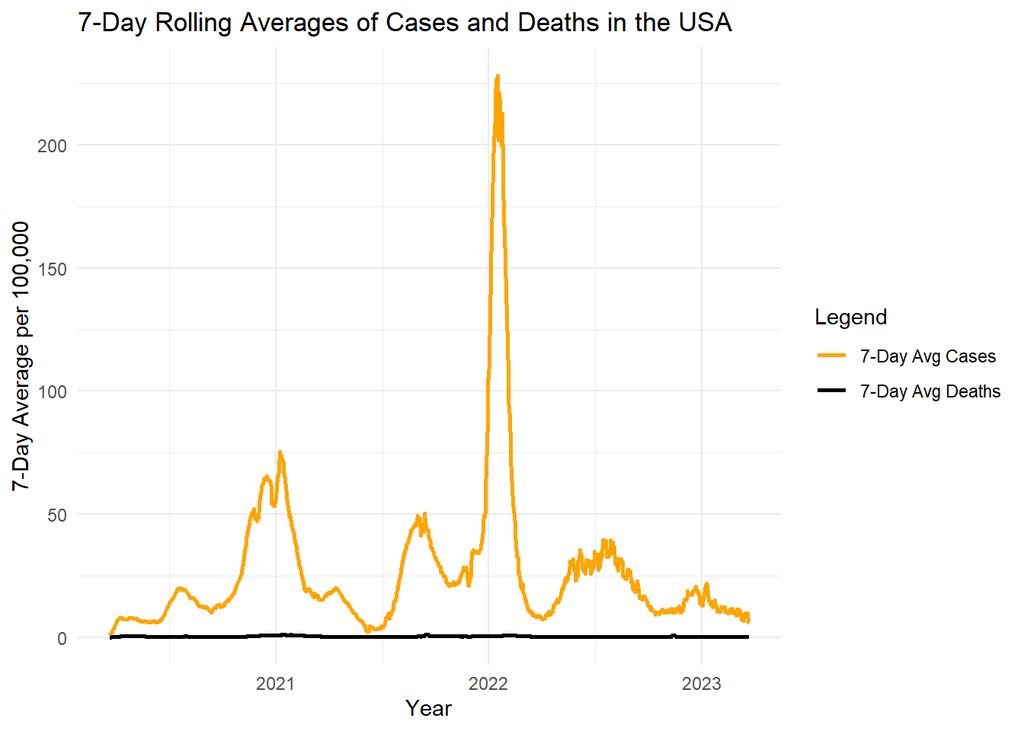

```r
# Create a visualization to compare the seven-day average cases and deaths per 100,000 people.
per_100k_vis <-  totals_per_capita %>%
  filter(!is.na(avg_cases_per_7day_per_100k)) %>%
  ggplot(aes(x = date)) + #set the x axis for the time of the years
  geom_line(aes(y = avg_cases_per_7day_per_100k, color = "7-Day Avg Cases"), linewidth = 1) +
  geom_line(aes(y = avg_deaths_per_7day_per_100k, color = "7-Day Avg Deaths"), linewidth = 1) +
  labs(title = "7-Day Rolling Averages of Cases and Deaths in the USA",
       y = "7-Day Average per 100,000",
       x = "Year",
       color = "Legend"
       ) +
  scale_color_manual(
    values = c("7-Day Avg Cases" = "orange",
               "7-Day Avg Deaths" = "black")
  ) +
  theme_minimal()

per_100k_vis
```

#– Communicate your methodology, results, and interpretation here – The 7-day rolling averages from the tibble above,totals_per_capita, are used for the visualization. Orange is the 7-day rolling average of new cases. Black is the 7-day rolling average of deaths. Notice the peak of cases are in alignment with historic analyses. Again, the deaths tend to be near 1% of the cases at any given time.

# Part 2 - US State Comparison

While understanding the trends on a national level can be helpful in understanding how COVID-19 impacted the United States, it is important to remember that the virus arrived in the United States at different times. For the next part of your analysis, you will begin to look at COVID related deaths and cases at the state and county-levels.

## Question 1

###Your first task in Part 2 is to determine the top 10 states in terms of total deaths and cases between March 15, 2020, and December 31, 2021.

###Once you have both lists, briefly describe your methodology and your results.

```r
# Determine the top 10 states in terms of total deaths and cases between March 15, 2020, and December 31, 2021.
# To do this, transform your combined COVID-19 data to summarize total deaths and cases by state up to December 31, 2021.

state_totals <- COVID %>%
  filter(date >= "2020-03-15", date <= "2021-12-31") %>%
  arrange(county, state, date) %>% # Ensure the date is sorted ascending within each group
  group_by(county, state) %>% #group the unique combinations
  slice_tail(n = 1)  %>%   # Slice the last row in each group, which corresponds to the latest date
                            # Because the data is sorted by date, the last row is the max cumulative value.
  ungroup() %>%
  group_by(state) %>%
  summarise(
    state_total_cases = sum(cases, na.rm = TRUE), #add up all the different counties' last day of reporting to get around the cumulative data column
    state_total_deaths = sum(deaths, na.rm = TRUE)
  ) %>%
  ungroup() %>%
  arrange(state)

state_deaths_10 <- state_totals %>%
  select(state, state_total_deaths) %>%
  arrange(desc(state_total_deaths)) %>%
  head(n = 10)


state_cases_10 <- state_totals %>%
  select(state, state_total_cases) %>%
  arrange(desc(state_total_cases)) %>%
  head(n = 10)

head(state_totals, 10)
```

| state | state_total_cases | state_total_deaths |
| --- | --- | --- |
| Alabama | 896614 | 16455 |
| Alaska | 155589 | 953 |
| Arizona | 1381487 | 24229 |
| Arkansas | 559422 | 9148 |
| California | 5515613 | 76709 |
| Colorado | 933257 | 10480 |
| Connecticut | 508308 | 9158 |
| Delaware | 179660 | 2286 |
| District of Columbia | 94286 | 1211 |
| Florida | 4166387 | 62342 |

```r
state_cases_10
```

| state | state_total_cases |
| --- | --- |
| California | 5515613 |
| Texas | 4574881 |
| Florida | 4166387 |
| Illinois | 2154058 |
| Pennsylvania | 2036424 |
| Ohio | 2016095 |
| New York | 1924629 |
| Georgia | 1793593 |
| Michigan | 1704801 |
| North Carolina | 1685504 |

```r
state_deaths_10
```

| state | state_total_deaths |
| --- | --- |
| California | 76709 |
| Texas | 76062 |
| Florida | 62342 |
| Pennsylvania | 36705 |
| Georgia | 30276 |
| Illinois | 29850 |
| Ohio | 29440 |
| New Jersey | 29037 |
| Michigan | 28968 |
| Arizona | 24229 |

```r
# Your transformed data should look similar to the following tibble:
#
# A tibble: 51 x 4
#     state                  date       total_deaths  total_cases
#     <chr>                 <date>          <dbl>       <dbl>
#  1 California           2021-12-31        76709      5515613
#  2 Texas                2021-12-31        76062      4574881
#  3 Florida              2021-12-31        62504      4166392
#  4 New York             2021-12-31        58993      3473970
#  5 Illinois             2021-12-31        31017      2154058
#  6 Pennsylvania         2021-12-31        36705      2036424
#  7 Ohio                 2021-12-31        29447      2016095
#  8 Georgia              2021-12-31        30283      1798497
#  9 Michigan             2021-12-31        28984      1706355
# 10 North Carolina       2021-12-31        19436      1685504
# ... with 41 more rows
```

# Question 2

Determine the top 10 states in terms of deaths per 100,000 people and cases per 100,000 people between March 15, 2020, and December 31, 2021. @Line 604

Once you have both lists, briefly describe your methodology and your results. Do you expect the lists to be different than the one produced in Question 1? Which method, total or per 100,000 people, is a better method for reporting the statistics?

```r
# Determine the top 10 states in terms of deaths and cases per 100,000 people between March 15, 2020, and December 31, 2021. You should first tidy and transform the population estimates to include population totals by state. Use your relational data verbs (e.g. full_join()) to join the population estimates with the cases and death statistics using the state name as a key. Then, use case_when() and grepl() to add a population column to your table that only includes the estimated population for the associated year. Finally, mutate your table to calculate deaths and cases per 100,000 people and summarize by state.

#load in the CSV with state-wise population data from the lab rstudio files
pop_raw <- read.csv("data/fips_pops.csv")


#familiarize with the data
#pop_raw %>% arrange(desc(Estimate))
#pop_raw %>% arrange(desc(STATE))
#pop_raw %>% arrange(desc(Estimate))
#class(pop_raw$Estimate) #is "integer"

#tidy the data, year needs to be 2 columns
#tide the column names?
pop_state_tidy <- pop_raw %>%
  pivot_wider(  #take a column to make more columns from that data
    names_from = Year, #tell what goes into column labels
    values_from = Estimate #select the values to fill the year columns
  ) %>%
  rename(
    pop_in_2020 = '2020',
    pop_in_2021 = '2021'
  ) %>%
  select(STNAME, CTYNAME, pop_in_2021, fips) %>% #limit the view for a cleaner workspace
  mutate(
    fips = as.character(fips),
    fips = str_pad(fips, width = 5, side = "left", pad = "0")
  ) %>%
  group_by(STNAME) %>%
  summarise(
    state_pops_2021 = sum(pop_in_2021, na.rm = TRUE)
  ) %>%
  ungroup()


pop_county_tidy <- pop_raw %>%
    mutate(
    fips = as.character(fips)
  ) %>%
  pivot_wider(  #take a column to make more columns from that data
    names_from = Year, #tell what goes into column labels
    values_from = Estimate #select the values to fill the year columns
  ) %>%
  rename(
    pop_in_2020 = '2020',
    pop_in_2021 = '2021'
  ) %>%
  select(STNAME, CTYNAME, pop_in_2021, fips) %>% #limit the view for a cleaner workspace
  ungroup()

class(pop_state_tidy$fips) #null bc the grouping of state omits fips and CTNAME
```

```
## [1] "NULL"
```

```r
pop_state_tidy #view the tibble for appropriateness
```

| STNAME | state_pops_2021 |
| --- | --- |
| Alabama | 5039877 |
| Alaska | 732673 |
| Arizona | 7276316 |
| Arkansas | 3025891 |
| California | 39237836 |
| Colorado | 5812069 |
| Connecticut | 3605597 |
| Delaware | 1003384 |
| District of Columbia | 670050 |
| Florida | 21781128 |

[output cut: 41 more lines]

```r
class(pop_county_tidy$fips) #char
```

```
## [1] "character"
```

```r
pop_county_tidy #view the tibble for appropriateness
```

| STNAME | CTYNAME | pop_in_2021 | fips |
| --- | --- | --- | --- |
| Alabama | Autauga County | 59095 | 1001 |
| Alabama | Baldwin County | 239294 | 1003 |
| Alabama | Barbour County | 24964 | 1005 |
| Alabama | Bibb County | 22477 | 1007 |
| Alabama | Blount County | 59041 | 1009 |
| Alabama | Bullock County | 10320 | 1011 |
| Alabama | Butler County | 18884 | 1013 |
| Alabama | Calhoun County | 115972 | 1015 |
| Alabama | Chambers County | 34541 | 1017 |
| Alabama | Cherokee County | 24996 | 1019 |

[output cut: 3133 more lines]

```r
state_cases_10
```

| state | state_total_cases |
| --- | --- |
| California | 5515613 |
| Texas | 4574881 |
| Florida | 4166387 |
| Illinois | 2154058 |
| Pennsylvania | 2036424 |
| Ohio | 2016095 |
| New York | 1924629 |
| Georgia | 1793593 |
| Michigan | 1704801 |
| North Carolina | 1685504 |

```r
state_deaths_10 #view the table to use with the newly cleaned pop data
```

| state | state_total_deaths |
| --- | --- |
| California | 76709 |
| Texas | 76062 |
| Florida | 62342 |
| Pennsylvania | 36705 |
| Georgia | 30276 |
| Illinois | 29850 |
| Ohio | 29440 |
| New Jersey | 29037 |
| Michigan | 28968 |
| Arizona | 24229 |

```r
# Determine the top 10 states in terms of deaths and cases per 100,000 people between March 15, 2020, and December 31, 2021. You should first tidy and transform the population estimates to include population totals by state. Use your relational data verbs (e.g. full_join()) to join the population estimates with the cases and death statistics using the state name as a key. Then, use case_when() and grepl() to add a population column to your table that only includes the estimated population for the associated year. Finally, mutate your table to calculate deaths and cases per 100,000 people and summarize by state.

state_cases_100k <- state_cases_10 %>%
  left_join(
    pop_state_tidy, by = c("state" = "STNAME")
    ) %>%
  mutate(
    state_cases_per_100k = ((state_total_cases / state_pops_2021 * 1e5))
  )

state_deaths_100k <- state_deaths_10 %>%
  left_join(
    pop_state_tidy, by = c("state" = "STNAME")
    ) %>%
  mutate(
    state_deaths_per_100k = ((state_total_deaths / state_pops_2021 * 1e5))
  )

state_cases_100k
```

| state | state_total_cases | state_pops_2021 | state_cases_per_100k |
| --- | --- | --- | --- |
| California | 5515613 | 39237836 | 14056.87 |
| Texas | 4574881 | 29527941 | 15493.40 |
| Florida | 4166387 | 21781128 | 19128.43 |
| Illinois | 2154058 | 12671469 | 16999.28 |
| Pennsylvania | 2036424 | 12964056 | 15708.23 |
| Ohio | 2016095 | 11780017 | 17114.53 |
| New York | 1924629 | 19835913 | 9702.75 |
| Georgia | 1793593 | 10799566 | 16608.01 |
| Michigan | 1704801 | 10050811 | 16961.83 |
| North Carolina | 1685504 | 10551162 | 15974.58 |

```r
state_deaths_100k
```

| state | state_total_deaths | state_pops_2021 | state_deaths_per_100k |
| --- | --- | --- | --- |
| California | 76709 | 39237836 | 195.4975 |
| Texas | 76062 | 29527941 | 257.5933 |
| Florida | 62342 | 21781128 | 286.2203 |
| Pennsylvania | 36705 | 12964056 | 283.1290 |
| Georgia | 30276 | 10799566 | 280.3446 |
| Illinois | 29850 | 12671469 | 235.5686 |
| Ohio | 29440 | 11780017 | 249.9147 |
| New Jersey | 29037 | 9267130 | 313.3333 |
| Michigan | 28968 | 10050811 | 288.2155 |
| Arizona | 24229 | 7276316 | 332.9844 |

```r
# Your transformed data should look similar to the following tibble:
#
# A tibble: 51 x 4
#     state                   date           deaths_per_100k  cases_per_100k
#     <chr>                  <date>               <dbl>          <dbl>
#  1 North Dakota          2021-12-31             265.           22482.
#  2 Alaska                2021-12-31             130.           21310.
#  3 Rhode Island          2021-12-31             280.           21093.
#  4 South Dakota          2021-12-31             278.           20014.
#  5 Wyoming               2021-12-31             264.           19979.
#  6 Tennessee             2021-12-31             296.           19783.
#  7 Kentucky              2021-12-31             269.           19173.
#  8 Florida               2021-12-31             287.           19128.
#  9 Utah                  2021-12-31             113.           19088.
# 10 Wisconsin             2021-12-31             190.           19008.
# ... with 41 more rows
```

# Question 3

Now, select a state and calculate the seven-day averages for new cases and deaths per 100,000 people. Once you have calculated the averages, create a visualization using ggplot2 to represent the data.

```r
# Select a state and then filter by state and date range your data from Question 1. Calculate the seven-day average following the same procedure as Part 1.

#COVID %>% filter(state == "West Virginia") #see if WV is WV in the original table

#GOAL: 7day rolling average for West Virginia use tibble COVID from mod 1's prompts
#make daily totals for WV
WV_daily_total_state <- COVID %>%
  filter(state == "West Virginia") %>%
  arrange(date, county) %>%
  group_by(date) %>%
  summarise(
    daily_cases_WV = sum(cases, na.rm = TRUE),
    daily_deaths_WV = sum(deaths, na.rm = TRUE)
  )

#calculate the change daily and weekly
WV_daily_1_7_state <- WV_daily_total_state %>% #label a new tibble for the objective
  arrange(date >= "2020-03-15") %>% #grab the columns of interest
  mutate( #make a new column with the difference in cases using lag()
    delta_cases_1 = daily_cases_WV - lag(daily_cases_WV, n = 1),
    delta_deaths_1 = daily_deaths_WV - lag(daily_deaths_WV, n = 1),
    delta_cases_7 = (daily_cases_WV - lag(daily_cases_WV, n = 7))/7, #divide calc by 7 to get the average over 7 days
    delta_deaths_7 = (daily_deaths_WV - lag(daily_deaths_WV, n = 7))/7, #divide calc by 7 to get the average over 7 days
    )

WV_daily_total_state #change per day
```

| date | daily_cases_WV | daily_deaths_WV |
| --- | --- | --- |
| 2020-03-17 | 1 | 0 |
| 2020-03-18 | 2 | 0 |
| 2020-03-19 | 5 | 0 |
| 2020-03-20 | 8 | 0 |
| 2020-03-21 | 12 | 0 |
| 2020-03-22 | 16 | 0 |
| 2020-03-23 | 16 | 0 |
| 2020-03-24 | 39 | 0 |
| 2020-03-25 | 51 | 0 |
| 2020-03-26 | 76 | 0 |

[output cut: 1092 more lines]

```r
WV_daily_1_7_state #rolling 7day avg
```

| date | daily_cases_WV | daily_deaths_WV | delta_cases_1 | delta_deaths_1 | delta_cases_7 | delta_deaths_7 |
| --- | --- | --- | --- | --- | --- | --- |
| 2020-03-17 | 1 | 0 | NA | NA | NA | NA |
| 2020-03-18 | 2 | 0 | 1 | 0 | NA | NA |
| 2020-03-19 | 5 | 0 | 3 | 0 | NA | NA |
| 2020-03-20 | 8 | 0 | 3 | 0 | NA | NA |
| 2020-03-21 | 12 | 0 | 4 | 0 | NA | NA |
| 2020-03-22 | 16 | 0 | 4 | 0 | NA | NA |
| 2020-03-23 | 16 | 0 | 0 | 0 | NA | NA |
| 2020-03-24 | 39 | 0 | 23 | 0 | 5.428571 | 0.0000000 |
| 2020-03-25 | 51 | 0 | 12 | 0 | 7.000000 | 0.0000000 |
| 2020-03-26 | 76 | 0 | 25 | 0 | 10.142857 | 0.0000000 |

[output cut: 1092 more lines]

```r
# Your transformed data should look similar to the following tibble:
#
# A tibble: 656 × 9
#     state    date       total_deaths total_cases population deaths_per_100k cases_per_100k deaths_7_day  cases_7_day
#     <chr>    <date>            <dbl>    <dbl>      <dbl>         <dbl>          <dbl>        <dbl>         <dbl>
#  1 Colorado 2020-03-15            2      136      5784308        0.0346          2.35         NA            NA
#  2 Colorado 2020-03-16            2      161      5784308        0.0346          2.78         NA            NA
#  3 Colorado 2020-03-17            3      183      5784308        0.0519          3.16         NA            NA
#  4 Colorado 2020-03-18            3      216      5784308        0.0519          3.73         NA            NA
#  5 Colorado 2020-03-19            5      278      5784308        0.0864          4.81         NA            NA
#  6 Colorado 2020-03-20            5      364      5784308        0.0864          6.29         NA            NA
#  7 Colorado 2020-03-21            6      475      5784308        0.104           8.21         NA            NA
#  8 Colorado 2020-03-22            7      591      5784308        0.121           10.2       0.0123         1.12
#  9 Colorado 2020-03-23           10      721      5784308        0.173           12.5       0.0198         1.38
# 10 Colorado 2020-03-24           11      912      5784308        0.190           15.8       0.0198         1.80
# … with 646 more rows
```

##– Communicate your methodology, results, and interpretation here – ###To start, I used the original tidy COVID tibble from module 1. This tibble was filtered by state for only West Virginia, WV. The daily county data were summed for a state total daily cases or deaths. Then the lag() function was employed to calculate the daily change and rolling 7-day averages for cases or deaths. As with the other data, deaths hovered around 1 percent of the cases peaking at about 33deaths/7day. Later, the data will be normalized for more straightforward comparisons.

# Question 4

Using the same state, identify the top 5 counties in terms of deaths and cases per 100,000 people.

```r
# Using the same state as Question 2, filter your state and date range from the combined data set from Part 1 and summarize cases and deaths. Produce two lists arranged by deaths and cases. When transforming the data, be sure to include the "fips" column as you will need this to complete Question 5.
#state filter for all counties West Virginia

#1 max county cases/deaths
#2 sort descending n = 5

WV_county_totals <- COVID %>% #by county
  filter(date >= "2020-03-15", date <= "2021-12-31", state == "West Virginia") %>%
  arrange(state, county, date) %>% # Ensure the date is sorted ascending within each group
  group_by(state, county, fips) %>% #group the unique combinations
  slice_tail(n = 1)  %>%   # Slice the last row in each group, which corresponds to the latest date
                            # Because the data is sorted by date, the last row is the max cumulative value.
  ungroup() %>%
  select(date,
         state,
         county,
         cases,
         deaths,
         fips) %>%
  mutate(
    fips = as.character(fips)
  )

WV_county_cases <- WV_county_totals %>%
  select(state, county, cases, fips) %>%
  arrange(desc(cases)) %>%
  head(5)

WV_county_deaths <- WV_county_totals %>%
  select(state, county, deaths, fips) %>%
  arrange(desc(deaths)) %>%
  head(5)

WV_county_totals
```

| date | state | county | cases | deaths | fips |
| --- | --- | --- | --- | --- | --- |
| 2021-12-31 | West Virginia | Barbour | 3257 | 56 | 54001 |
| 2021-12-31 | West Virginia | Berkeley | 24218 | 215 | 54003 |
| 2021-12-31 | West Virginia | Boone | 4291 | 62 | 54005 |
| 2021-12-31 | West Virginia | Braxton | 2697 | 31 | 54007 |
| 2021-12-31 | West Virginia | Brooke | 3671 | 86 | 54009 |
| 2021-12-31 | West Virginia | Cabell | 17685 | 299 | 54011 |
| 2021-12-31 | West Virginia | Calhoun | 1219 | 9 | 54013 |
| 2021-12-31 | West Virginia | Clay | 1640 | 26 | 54015 |
| 2021-12-31 | West Virginia | Doddridge | 1551 | 13 | 54017 |
| 2021-12-31 | West Virginia | Fayette | 7687 | 151 | 54019 |

[output cut: 45 more lines]

```r
WV_county_cases
```

| state | county | cases | fips |
| --- | --- | --- | --- |
| West Virginia | Kanawha | 29101 | 54039 |
| West Virginia | Berkeley | 24218 | 54003 |
| West Virginia | Cabell | 17685 | 54011 |
| West Virginia | Monongalia | 15710 | 54061 |
| West Virginia | Wood | 15367 | 54107 |

```r
WV_county_deaths
```

| state | county | deaths | fips |
| --- | --- | --- | --- |
| West Virginia | Kanawha | 573 | 54039 |
| West Virginia | Cabell | 299 | 54011 |
| West Virginia | Wood | 277 | 54107 |
| West Virginia | Raleigh | 225 | 54081 |
| West Virginia | Berkeley | 215 | 54003 |

```r
# Your transformed data should be similar to the following tibbles:
#
# Arranged by deaths:
# A tibble: 64 × 4
#     county       date       fips    total_deaths   total_cases
#     <chr>       <date>      <chr>       <dbl>         <dbl>
#  1 El Paso    2021-12-20    08041       1355         119772
#  2 Denver     2021-12-20    08031       1065         106747
#  3 Jefferson  2021-12-20    08059       1061         76732
#  4 Adams      2021-12-20    08001       1057         90476
#  5 Arapahoe   2021-12-20    08005       1046         95769
#  6 Pueblo     2021-12-20    08101        643         30739
#  7 Weld       2021-12-20    08123        569         55599
#  8 Mesa       2021-12-20    08077        445         29542
#  9 Larimer    2021-12-20    08069        393         47444
# 10 Douglas    2021-12-20    08035        361         48740
# … with 54 more rows
#
#
# Arranged by cases:
# A tibble: 64 × 4
#     county       date       fips   total_deaths   total_cases
#     <chr>       <date>      <chr>     <dbl>         <dbl>
#  1 El Paso    2021-12-20    08041     1355         119772
#  2 Denver     2021-12-20    08031     1065         106747
#  3 Arapahoe   2021-12-20    08005     1046          95769
#  4 Adams      2021-12-20    08001     1057          90476
#  5 Jefferson  2021-12-20    08059     1061          76732
#  6 Weld       2021-12-20    08123      569          55599
#  7 Douglas    2021-12-20    08035      361          48740
#  8 Larimer    2021-12-20    08069      393          47444
#  9 Boulder    2021-12-20    08013      323          36754
# 10 Pueblo     2021-12-20    08101      643          30739
# … with 54 more rows
```

##– Communicate your methodology, results, and interpretation here – ###To start, I used the original tidy COVID tibble from module 1. This tibble was filtered by state for only West Virginia, WV. Then the data were filtered, arranged, and sliced for the final, cumulative data point for cases or deaths. Kanawha had the most cases at about 29 thousand. Kanawha also had the most deaths at about 573.

# Question 5

Modify the code below for the map projection to plot county-level deaths and cases per 100,000 people for your state.

```r
#class(WV_county_pops$fips) #was int, now char. confirm the join data types are the SAME!!
#class(WV_county_totals$fips) #char

WV_county_pops <- pop_raw %>%
  filter(STNAME == "West Virginia", Year == "2021") %>%
  mutate(
    fips = as.character(fips))

WV_county_100k <- WV_county_totals %>%
  left_join(
    WV_county_pops, by = "fips"
  ) %>%
  mutate(
    county_cases_100k = ((cases / Estimate *1e5)),
    county_deaths_100k = ((deaths / Estimate *1e5)),
  ) %>%
  select(state, county, fips, county_cases_100k, county_deaths_100k)

WV_deadlist_5 <- WV_county_100k %>% arrange(county_deaths_100k) %>% head(5)
WV_highest_cases_5 <- WV_county_100k %>% arrange(county_cases_100k) %>% head(5)

WV_county_pops
```

| STNAME | CTYNAME | fips | STATE | COUNTY | Year | Estimate |
| --- | --- | --- | --- | --- | --- | --- |
| West Virginia | Barbour County | 54001 | 54 | 1 | 2021 | 15468 |
| West Virginia | Berkeley County | 54003 | 54 | 3 | 2021 | 126069 |
| West Virginia | Boone County | 54005 | 54 | 5 | 2021 | 21312 |
| West Virginia | Braxton County | 54007 | 54 | 7 | 2021 | 12247 |
| West Virginia | Brooke County | 54009 | 54 | 9 | 2021 | 22140 |
| West Virginia | Cabell County | 54011 | 54 | 11 | 2021 | 93418 |
| West Virginia | Calhoun County | 54013 | 54 | 13 | 2021 | 6176 |
| West Virginia | Clay County | 54015 | 54 | 15 | 2021 | 7892 |
| West Virginia | Doddridge County | 54017 | 54 | 17 | 2021 | 7735 |
| West Virginia | Fayette County | 54019 | 54 | 19 | 2021 | 39927 |

[output cut: 45 more lines]

```r
WV_county_100k
```

| state | county | fips | county_cases_100k | county_deaths_100k |
| --- | --- | --- | --- | --- |
| West Virginia | Barbour | 54001 | 21056.37 | 362.0378 |
| West Virginia | Berkeley | 54003 | 19210.12 | 170.5415 |
| West Virginia | Boone | 54005 | 20134.20 | 290.9159 |
| West Virginia | Braxton | 54007 | 22021.72 | 253.1232 |
| West Virginia | Brooke | 54009 | 16580.85 | 388.4372 |
| West Virginia | Cabell | 54011 | 18931.04 | 320.0668 |
| West Virginia | Calhoun | 54013 | 19737.69 | 145.7254 |
| West Virginia | Clay | 54015 | 20780.54 | 329.4475 |
| West Virginia | Doddridge | 54017 | 20051.71 | 168.0672 |
| West Virginia | Fayette | 54019 | 19252.64 | 378.1902 |

[output cut: 45 more lines]

```r
WV_county_pops
```

| STNAME | CTYNAME | fips | STATE | COUNTY | Year | Estimate |
| --- | --- | --- | --- | --- | --- | --- |
| West Virginia | Barbour County | 54001 | 54 | 1 | 2021 | 15468 |
| West Virginia | Berkeley County | 54003 | 54 | 3 | 2021 | 126069 |
| West Virginia | Boone County | 54005 | 54 | 5 | 2021 | 21312 |
| West Virginia | Braxton County | 54007 | 54 | 7 | 2021 | 12247 |
| West Virginia | Brooke County | 54009 | 54 | 9 | 2021 | 22140 |
| West Virginia | Cabell County | 54011 | 54 | 11 | 2021 | 93418 |
| West Virginia | Calhoun County | 54013 | 54 | 13 | 2021 | 6176 |
| West Virginia | Clay County | 54015 | 54 | 15 | 2021 | 7892 |
| West Virginia | Doddridge County | 54017 | 54 | 17 | 2021 | 7735 |
| West Virginia | Fayette County | 54019 | 54 | 19 | 2021 | 39927 |

[output cut: 45 more lines]

```r
WV_highest_cases_5
```

| state | county | fips | county_cases_100k | county_deaths_100k |
| --- | --- | --- | --- | --- |
| West Virginia | Summers | 54089 | 14502.86 | 319.1132 |
| West Virginia | Roane | 54087 | 14663.98 | 201.4678 |
| West Virginia | Monongalia | 54061 | 14766.84 | 148.5144 |
| West Virginia | Jefferson | 54037 | 15710.13 | 166.1813 |
| West Virginia | Kanawha | 54039 | 16353.29 | 321.9969 |

```r
WV_deadlist_5
```

| state | county | fips | county_cases_100k | county_deaths_100k |
| --- | --- | --- | --- | --- |
| West Virginia | Calhoun | 54013 | 19737.69 | 145.7254 |
| West Virginia | Monongalia | 54061 | 14766.84 | 148.5144 |
| West Virginia | Jefferson | 54037 | 15710.13 | 166.1813 |
| West Virginia | Doddridge | 54017 | 20051.71 | 168.0672 |
| West Virginia | Berkeley | 54003 | 19210.12 | 170.5415 |

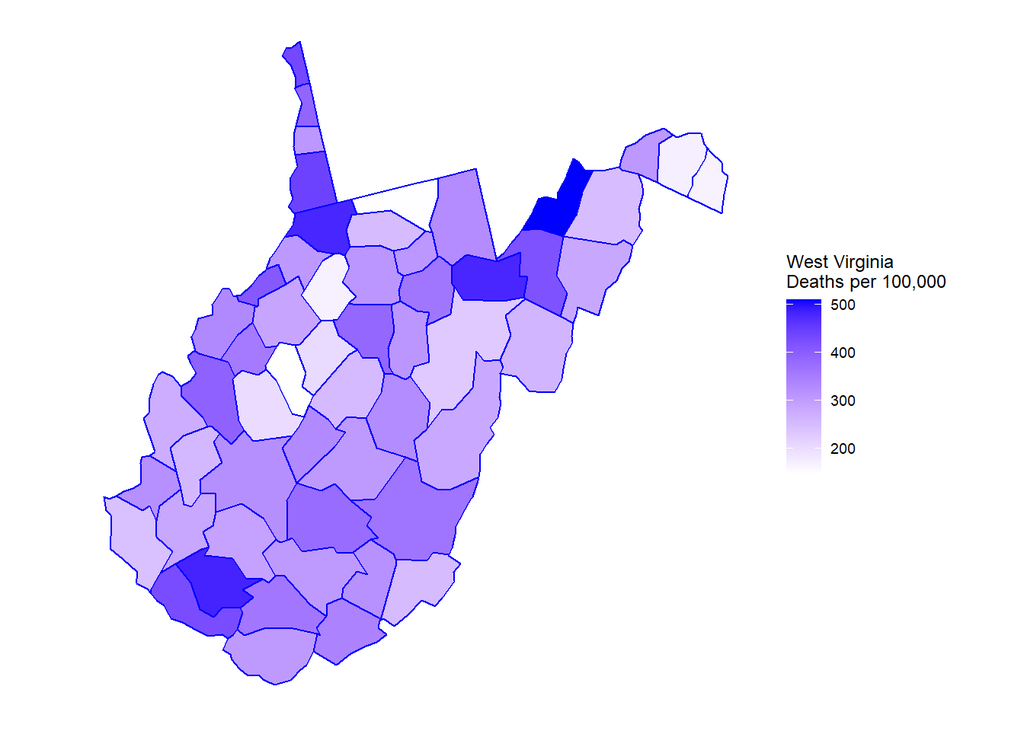

```r
# Copy and modify the code below for your state.
#
# plot_usmap arguments:
#   regions: can be one of ("states", "state", "counties", "county"). The default is "states"
#   include: The regions to include in the resulting map. If regions is "states"/"state", the value can be either a state name, abbreviation or FIPS code. For counties, the FIPS must be provided as there can be multiple counties with the same name.
#   data: values to plot on the map = WV_county_totals
#   values: the name of the column that contains the values to be associated with a given region. county_cases, county_deaths
#   color: the map outline color.
#
# Reference the plot_usmap documentation for further information using ?plot_usmap

plot_usmap(regions = "county", include="WV", data = WV_county_100k, values = "county_deaths_100k", color = "blue") +
  scale_fill_continuous(low = "white", high = "blue", name = "West Virginia \nDeaths per 100,000") +
  theme(
    legend.position = "right"
  )
```

# Question 6

##Finally, select three (four?) other states and calculate the seven-day averages for new deaths and cases per 100,000 people for between March 15, 2020, and December 31, 2021.

```r
my_four_states <- c("Mississippi", "Alabama", "Louisiana", "Georgia")

#7day averages for the 4 states
MS_pop <- pop_state_tidy %>%
  filter(STNAME == "Mississippi")
MS_pop
```

| STNAME | state_pops_2021 |
| --- | --- |
| Mississippi | 2949965 |

```r
MS_pop_value <- 2949965
MS_pop_value
```

```
## [1] 2949965
```

```r
MS_daily_1_7 <- COVID %>%
  filter(
    date >= "2020-03-15",
    date <= "2021-12-31",
    state == "Mississippi"
    ) %>%
  arrange(
    county,
    state,
    date
    ) %>%
 # Ensure the date is sorted ascending within each group
  group_by(  #group the unique combinations to add up all the county deaths and cases
    date,
    state
    ) %>%
  summarise(
    state_daily_cases = sum(cases, na.rm = TRUE), #add up all the different counties' last day of reporting to get around the cumulative data column
    state_daily_deaths = sum(deaths, na.rm = TRUE),
    .groups = 'drop'
  ) %>%
  ungroup(
  ) %>%
  arrange(
    state
  ) %>%
  mutate( #make a new column with the difference in cases using lag()
    delta_cases_1_100k = (state_daily_cases - lag(state_daily_cases, n = 1)) / MS_pop_value *1e5,
    delta_deaths_1_100k = (state_daily_deaths - lag(state_daily_deaths, n = 1)) / MS_pop_value *1e5,
    delta_cases_7_100k = (state_daily_cases - lag(state_daily_cases, n = 7))/7 / MS_pop_value *1e5, #divide calc by 7 to get the average over 7 days
    delta_deaths_7_100k = (state_daily_deaths - lag(state_daily_deaths, n = 7))/7 / MS_pop_value *1e5, #divide calc by 7 to get the average over 7 days
    ) %>%
  select(
    date,
    state,
    delta_cases_7_100k,
    delta_deaths_7_100k
  )

AL_pop <- pop_state_tidy %>%
  filter(STNAME == "Alabama")
AL_pop
```

| STNAME | state_pops_2021 |
| --- | --- |
| Alabama | 5039877 |

```r
AL_pop_value <- 5039877
AL_pop_value
```

```
## [1] 5039877
```

```r
AL_daily_1_7 <- COVID %>%
  filter(
    date >= "2020-03-15",
    date <= "2021-12-31",
    state == "Alabama"
    ) %>%
  arrange(
    county,
    state,
    date
    ) %>%
 # Ensure the date is sorted ascending within each group
  group_by(  #group the unique combinations to add up all the county deaths and cases
    date,
    state
    ) %>%
  summarise(
    state_daily_cases = sum(cases, na.rm = TRUE), #add up all the different counties' last day of reporting to get around the cumulative data column
    state_daily_deaths = sum(deaths, na.rm = TRUE),
    .groups = 'drop'
  ) %>%
  ungroup(
  ) %>%
  arrange(
    state
  ) %>%
  mutate( #make a new column with the difference in cases using lag()
    delta_cases_1_100k = (state_daily_cases - lag(state_daily_cases, n = 1)) / MS_pop_value *1e5,
    delta_deaths_1_100k = (state_daily_deaths - lag(state_daily_deaths, n = 1)) / MS_pop_value *1e5,
    delta_cases_7_100k = (state_daily_cases - lag(state_daily_cases, n = 7))/7 / MS_pop_value *1e5, #divide calc by 7 to get the average over 7 days
    delta_deaths_7_100k = (state_daily_deaths - lag(state_daily_deaths, n = 7))/7 / MS_pop_value *1e5, #divide calc by 7 to get the average over 7 days
    ) %>%
  select(
    date,
    state,
    delta_cases_7_100k,
    delta_deaths_7_100k
  )

LA_pop <- pop_state_tidy %>%
  filter(STNAME == "Louisiana")
LA_pop
```

| STNAME | state_pops_2021 |
| --- | --- |
| Louisiana | 4624047 |

```r
LA_pop_value <- 4624047
LA_pop_value
```

```
## [1] 4624047
```

```r
LA_daily_1_7 <- COVID %>%
  filter(
    date >= "2020-03-15",
    date <= "2021-12-31",
    state == "Louisiana"
    ) %>%
  arrange(
    county,
    state,
    date
    ) %>%
 # Ensure the date is sorted ascending within each group
  group_by(  #group the unique combinations to add up all the county deaths and cases
    date,
    state
    ) %>%
  summarise(
    state_daily_cases = sum(cases, na.rm = TRUE), #add up all the different counties' last day of reporting to get around the cumulative data column
    state_daily_deaths = sum(deaths, na.rm = TRUE),
    .groups = 'drop'
  ) %>%
  ungroup(
  ) %>%
  arrange(
    state
  ) %>%
  mutate( #make a new column with the difference in cases using lag()
    delta_cases_1_100k = (state_daily_cases - lag(state_daily_cases, n = 1)) / MS_pop_value *1e5,
    delta_deaths_1_100k = (state_daily_deaths - lag(state_daily_deaths, n = 1)) / MS_pop_value *1e5,
    delta_cases_7_100k = (state_daily_cases - lag(state_daily_cases, n = 7))/7 / MS_pop_value *1e5, #divide calc by 7 to get the average over 7 days
    delta_deaths_7_100k = (state_daily_deaths - lag(state_daily_deaths, n = 7))/7 / MS_pop_value *1e5, #divide calc by 7 to get the average over 7 days
    ) %>%
  select(
    date,
    state,
    delta_cases_7_100k,
    delta_deaths_7_100k
  )

GA_pop <- pop_state_tidy %>%
  filter(STNAME == "Georgia")
GA_pop
```

| STNAME | state_pops_2021 |
| --- | --- |
| Georgia | 10799566 |

```r
GA_pop_value <- 10799566
GA_pop_value
```

```
## [1] 10799566
```

```r
GA_daily_1_7 <- COVID %>%
  filter(
    date >= "2020-03-15",
    date <= "2021-12-31",
    state == "Georgia"
    ) %>%
  arrange(
    county,
    state,
    date
    ) %>%
 # Ensure the date is sorted ascending within each group
  group_by(  #group the unique combinations to add up all the county deaths and cases
    date,
    state
    ) %>%
  summarise(
    state_daily_cases = sum(cases, na.rm = TRUE), #add up all the different counties' last day of reporting to get around the cumulative data column
    state_daily_deaths = sum(deaths, na.rm = TRUE),
    .groups = 'drop'
  ) %>%
  ungroup(
  ) %>%
  arrange(
    state
  ) %>%
  mutate( #make a new column with the difference in cases using lag()
    delta_cases_1_100k = (state_daily_cases - lag(state_daily_cases, n = 1)) / MS_pop_value *1e5,
    delta_deaths_1_100k = (state_daily_deaths - lag(state_daily_deaths, n = 1)) / MS_pop_value *1e5,
    delta_cases_7_100k = (state_daily_cases - lag(state_daily_cases, n = 7))/7 / MS_pop_value *1e5, #divide calc by 7 to get the average over 7 days
    delta_deaths_7_100k = (state_daily_deaths - lag(state_daily_deaths, n = 7))/7 / MS_pop_value *1e5, #divide calc by 7 to get the average over 7 days
    ) %>%
  select(
    date,
    state,
    delta_cases_7_100k,
    delta_deaths_7_100k
  )

#max(MS_daily_1_7$delta_deaths_7_100k, na.rm = TRUE)
#max(AL_daily_1_7$delta_deaths_7_100k, na.rm = TRUE)
#max(LA_daily_1_7$delta_deaths_7_100k, na.rm = TRUE)
#max(GA_daily_1_7$delta_deaths_7_100k, na.rm = TRUE)

#max(MS_daily_1_7$delta_cases_7_100k, na.rm = TRUE)
#max(AL_daily_1_7$delta_cases_7_100k, na.rm = TRUE)
#max(LA_daily_1_7$delta_cases_7_100k, na.rm = TRUE)
#max(GA_daily_1_7$delta_cases_7_100k, na.rm = TRUE)

four_states_tibbles <- list(MS_daily_1_7, AL_daily_1_7, LA_daily_1_7, GA_daily_1_7)
combine_four_states <- bind_rows(four_states_tibbles)


(MS_daily_1_7)
```

| date | state | delta_cases_7_100k | delta_deaths_7_100k |
| --- | --- | --- | --- |
| 2020-03-15 | Mississippi | NA | NA |
| 2020-03-16 | Mississippi | NA | NA |
| 2020-03-17 | Mississippi | NA | NA |
| 2020-03-18 | Mississippi | NA | NA |
| 2020-03-19 | Mississippi | NA | NA |
| 2020-03-20 | Mississippi | NA | NA |
| 2020-03-21 | Mississippi | NA | NA |
| 2020-03-22 | Mississippi | 0.9540065 | 0.004842672 |
| 2020-03-23 | Mississippi | 1.1477134 | 0.004842672 |
| 2020-03-24 | Mississippi | 1.4479591 | 0.004842672 |

[output cut: 647 more lines]

```r
(AL_daily_1_7)
```

| date | state | delta_cases_7_100k | delta_deaths_7_100k |
| --- | --- | --- | --- |
| 2020-03-15 | Alabama | NA | NA |
| 2020-03-16 | Alabama | NA | NA |
| 2020-03-17 | Alabama | NA | NA |
| 2020-03-18 | Alabama | NA | NA |
| 2020-03-19 | Alabama | NA | NA |
| 2020-03-20 | Alabama | NA | NA |
| 2020-03-21 | Alabama | NA | NA |
| 2020-03-22 | Alabama | 0.6489181 | 0.000000000 |
| 2020-03-23 | Alabama | 0.8087263 | 0.000000000 |
| 2020-03-24 | Alabama | 0.9830625 | 0.000000000 |

[output cut: 647 more lines]

```r
(LA_daily_1_7)
```

| date | state | delta_cases_7_100k | delta_deaths_7_100k |
| --- | --- | --- | --- |
| 2020-03-15 | Louisiana | NA | NA |
| 2020-03-16 | Louisiana | NA | NA |
| 2020-03-17 | Louisiana | NA | NA |
| 2020-03-18 | Louisiana | NA | NA |
| 2020-03-19 | Louisiana | NA | NA |
| 2020-03-20 | Louisiana | NA | NA |
| 2020-03-21 | Louisiana | NA | NA |
| 2020-03-22 | Louisiana | 3.501252 | 0.0871681 |
| 2020-03-23 | Louisiana | 4.954054 | 0.1501228 |
| 2020-03-24 | Louisiana | 5.724039 | 0.1937069 |

[output cut: 647 more lines]

```r
(GA_daily_1_7)
```

| date | state | delta_cases_7_100k | delta_deaths_7_100k |
| --- | --- | --- | --- |
| 2020-03-15 | Georgia | NA | NA |
| 2020-03-16 | Georgia | NA | NA |
| 2020-03-17 | Georgia | NA | NA |
| 2020-03-18 | Georgia | NA | NA |
| 2020-03-19 | Georgia | NA | NA |
| 2020-03-20 | Georgia | NA | NA |
| 2020-03-21 | Georgia | NA | NA |
| 2020-03-22 | Georgia | 2.401966 | 0.1065388 |
| 2020-03-23 | Georgia | 3.079940 | 0.1065388 |
| 2020-03-24 | Georgia | 4.237338 | 0.1549655 |

[output cut: 647 more lines]

```r
combine_four_states
```

| date | state | delta_cases_7_100k | delta_deaths_7_100k |
| --- | --- | --- | --- |
| 2020-03-15 | Mississippi | NA | NA |
| 2020-03-16 | Mississippi | NA | NA |
| 2020-03-17 | Mississippi | NA | NA |
| 2020-03-18 | Mississippi | NA | NA |
| 2020-03-19 | Mississippi | NA | NA |
| 2020-03-20 | Mississippi | NA | NA |
| 2020-03-21 | Mississippi | NA | NA |
| 2020-03-22 | Mississippi | 0.9540065 | 0.004842672 |
| 2020-03-23 | Mississippi | 1.1477134 | 0.004842672 |
| 2020-03-24 | Mississippi | 1.4479591 | 0.004842672 |

[output cut: 2618 more lines]

#### Part 3 - Global Comparison

```r
# Import global COVID-19 statistics aggregated by the Center for Systems Science and Engineering (CSSE) at Johns Hopkins University.
# Import global population estimates from the World Bank.

csse_global_deaths <- read_csv("https://raw.githubusercontent.com/CSSEGISandData/COVID-19/master/csse_covid_19_data/csse_covid_19_time_series/time_series_covid19_deaths_global.csv")
csse_global_cases <- read_csv("https://raw.githubusercontent.com/CSSEGISandData/COVID-19/master/csse_covid_19_data/csse_covid_19_time_series/time_series_covid19_confirmed_global.csv")
csse_us_deaths <- read_csv("https://raw.githubusercontent.com/CSSEGISandData/COVID-19/master/csse_covid_19_data/csse_covid_19_time_series/time_series_covid19_deaths_US.csv")
csse_us_cases <- read_csv("https://raw.githubusercontent.com/CSSEGISandData/COVID-19/master/csse_covid_19_data/csse_covid_19_time_series/time_series_covid19_confirmed_US.csv")
global_population_estimates <- read_csv("data/global_population_estimates - copy.csv") %>%
  filter(
    !is.na(`2020`), #remove the NA
    !is.na(`2021`)
     ) %>%
  select(
    -c("series_code", "series_name")
  )
```

# Question 1

Using the state you selected in Part 2 Question 2 compare the daily number of cases and deaths reported from the CSSE and NY Times. ###west virginia is the state I used above

```r
#US_CASES clean
csse_us_cases_tidy <- csse_us_cases %>%
  pivot_longer(
    cols = -c(UID,iso2, iso3, code3, FIPS, Admin2, Province_State, Country_Region, Lat, Long_, Combined_Key), #pivot longer except these listed (the minus sign list)
    #no population column in csse_us_cases
    names_to = "date",
    values_to = "cases"
  ) %>%
  mutate(
    county = Admin2, #rename the county header to county
     country = Country_Region,
    date = as.Date(date, format = "%m/%d/%y") #format the date as a date dtype
  )

#for deaths too, pivot_longer
csse_us_deaths_tidy <- csse_us_deaths %>%
  pivot_longer(
    cols = -c(UID,iso2, iso3, code3, FIPS, Admin2, Province_State, Country_Region, Lat, Long_, Combined_Key, Population),
    #pivot longer except these listed (the minus sign list)
    #notice the population column in csse_us_deaths
    names_to = "date",
    values_to = "deaths"
  ) %>%
  mutate(
    county = Admin2, #rename the county header to county
    country = Country_Region,
    date = as.Date(date, format = "%m/%d/%y") #format the date as a date dtype
  )
#created in this block
head(csse_us_cases_tidy, 10)
```

| UID | iso2 | iso3 | code3 | FIPS | Admin2 | Province_State | Country_Region | Lat | Long_ | Combined_Key | date | cases | county | country |
| --- | --- | --- | --- | --- | --- | --- | --- | --- | --- | --- | --- | --- | --- | --- |
| 84001001 | US | USA | 840 | 1001 | Autauga | Alabama | US | 32.53953 | -86.64408 | Autauga, Alabama, US | 2020-01-22 | 0 | Autauga | US |
| 84001001 | US | USA | 840 | 1001 | Autauga | Alabama | US | 32.53953 | -86.64408 | Autauga, Alabama, US | 2020-01-23 | 0 | Autauga | US |
| 84001001 | US | USA | 840 | 1001 | Autauga | Alabama | US | 32.53953 | -86.64408 | Autauga, Alabama, US | 2020-01-24 | 0 | Autauga | US |
| 84001001 | US | USA | 840 | 1001 | Autauga | Alabama | US | 32.53953 | -86.64408 | Autauga, Alabama, US | 2020-01-25 | 0 | Autauga | US |
| 84001001 | US | USA | 840 | 1001 | Autauga | Alabama | US | 32.53953 | -86.64408 | Autauga, Alabama, US | 2020-01-26 | 0 | Autauga | US |
| 84001001 | US | USA | 840 | 1001 | Autauga | Alabama | US | 32.53953 | -86.64408 | Autauga, Alabama, US | 2020-01-27 | 0 | Autauga | US |
| 84001001 | US | USA | 840 | 1001 | Autauga | Alabama | US | 32.53953 | -86.64408 | Autauga, Alabama, US | 2020-01-28 | 0 | Autauga | US |
| 84001001 | US | USA | 840 | 1001 | Autauga | Alabama | US | 32.53953 | -86.64408 | Autauga, Alabama, US | 2020-01-29 | 0 | Autauga | US |
| 84001001 | US | USA | 840 | 1001 | Autauga | Alabama | US | 32.53953 | -86.64408 | Autauga, Alabama, US | 2020-01-30 | 0 | Autauga | US |
| 84001001 | US | USA | 840 | 1001 | Autauga | Alabama | US | 32.53953 | -86.64408 | Autauga, Alabama, US | 2020-01-31 | 0 | Autauga | US |

```r
head(csse_us_deaths_tidy, 10)
```

| UID | iso2 | iso3 | code3 | FIPS | Admin2 | Province_State | Country_Region | Lat | Long_ | Combined_Key | Population | date | deaths | county | country |
| --- | --- | --- | --- | --- | --- | --- | --- | --- | --- | --- | --- | --- | --- | --- | --- |
| 84001001 | US | USA | 840 | 1001 | Autauga | Alabama | US | 32.53953 | -86.64408 | Autauga, Alabama, US | 55869 | 2020-01-22 | 0 | Autauga | US |
| 84001001 | US | USA | 840 | 1001 | Autauga | Alabama | US | 32.53953 | -86.64408 | Autauga, Alabama, US | 55869 | 2020-01-23 | 0 | Autauga | US |
| 84001001 | US | USA | 840 | 1001 | Autauga | Alabama | US | 32.53953 | -86.64408 | Autauga, Alabama, US | 55869 | 2020-01-24 | 0 | Autauga | US |
| 84001001 | US | USA | 840 | 1001 | Autauga | Alabama | US | 32.53953 | -86.64408 | Autauga, Alabama, US | 55869 | 2020-01-25 | 0 | Autauga | US |
| 84001001 | US | USA | 840 | 1001 | Autauga | Alabama | US | 32.53953 | -86.64408 | Autauga, Alabama, US | 55869 | 2020-01-26 | 0 | Autauga | US |
| 84001001 | US | USA | 840 | 1001 | Autauga | Alabama | US | 32.53953 | -86.64408 | Autauga, Alabama, US | 55869 | 2020-01-27 | 0 | Autauga | US |
| 84001001 | US | USA | 840 | 1001 | Autauga | Alabama | US | 32.53953 | -86.64408 | Autauga, Alabama, US | 55869 | 2020-01-28 | 0 | Autauga | US |
| 84001001 | US | USA | 840 | 1001 | Autauga | Alabama | US | 32.53953 | -86.64408 | Autauga, Alabama, US | 55869 | 2020-01-29 | 0 | Autauga | US |
| 84001001 | US | USA | 840 | 1001 | Autauga | Alabama | US | 32.53953 | -86.64408 | Autauga, Alabama, US | 55869 | 2020-01-30 | 0 | Autauga | US |
| 84001001 | US | USA | 840 | 1001 | Autauga | Alabama | US | 32.53953 | -86.64408 | Autauga, Alabama, US | 55869 | 2020-01-31 | 0 | Autauga | US |

```r
#JOIN all pertinent data into 1 tibble
csse_us_tidy <- csse_us_cases_tidy %>%
  left_join(
    csse_us_deaths_tidy, by = c("FIPS", "date", "Province_State", "county", "country")
  ) %>%
  select(
    date,
    FIPS,
    county,
    Province_State,
    cases,
    deaths,
    country
  )

head(csse_us_cases_tidy, 10)
```

| UID | iso2 | iso3 | code3 | FIPS | Admin2 | Province_State | Country_Region | Lat | Long_ | Combined_Key | date | cases | county | country |
| --- | --- | --- | --- | --- | --- | --- | --- | --- | --- | --- | --- | --- | --- | --- |
| 84001001 | US | USA | 840 | 1001 | Autauga | Alabama | US | 32.53953 | -86.64408 | Autauga, Alabama, US | 2020-01-22 | 0 | Autauga | US |
| 84001001 | US | USA | 840 | 1001 | Autauga | Alabama | US | 32.53953 | -86.64408 | Autauga, Alabama, US | 2020-01-23 | 0 | Autauga | US |
| 84001001 | US | USA | 840 | 1001 | Autauga | Alabama | US | 32.53953 | -86.64408 | Autauga, Alabama, US | 2020-01-24 | 0 | Autauga | US |
| 84001001 | US | USA | 840 | 1001 | Autauga | Alabama | US | 32.53953 | -86.64408 | Autauga, Alabama, US | 2020-01-25 | 0 | Autauga | US |
| 84001001 | US | USA | 840 | 1001 | Autauga | Alabama | US | 32.53953 | -86.64408 | Autauga, Alabama, US | 2020-01-26 | 0 | Autauga | US |
| 84001001 | US | USA | 840 | 1001 | Autauga | Alabama | US | 32.53953 | -86.64408 | Autauga, Alabama, US | 2020-01-27 | 0 | Autauga | US |
| 84001001 | US | USA | 840 | 1001 | Autauga | Alabama | US | 32.53953 | -86.64408 | Autauga, Alabama, US | 2020-01-28 | 0 | Autauga | US |
| 84001001 | US | USA | 840 | 1001 | Autauga | Alabama | US | 32.53953 | -86.64408 | Autauga, Alabama, US | 2020-01-29 | 0 | Autauga | US |
| 84001001 | US | USA | 840 | 1001 | Autauga | Alabama | US | 32.53953 | -86.64408 | Autauga, Alabama, US | 2020-01-30 | 0 | Autauga | US |
| 84001001 | US | USA | 840 | 1001 | Autauga | Alabama | US | 32.53953 | -86.64408 | Autauga, Alabama, US | 2020-01-31 | 0 | Autauga | US |

```r
head(csse_us_deaths_tidy, 10)
```

| UID | iso2 | iso3 | code3 | FIPS | Admin2 | Province_State | Country_Region | Lat | Long_ | Combined_Key | Population | date | deaths | county | country |
| --- | --- | --- | --- | --- | --- | --- | --- | --- | --- | --- | --- | --- | --- | --- | --- |
| 84001001 | US | USA | 840 | 1001 | Autauga | Alabama | US | 32.53953 | -86.64408 | Autauga, Alabama, US | 55869 | 2020-01-22 | 0 | Autauga | US |
| 84001001 | US | USA | 840 | 1001 | Autauga | Alabama | US | 32.53953 | -86.64408 | Autauga, Alabama, US | 55869 | 2020-01-23 | 0 | Autauga | US |
| 84001001 | US | USA | 840 | 1001 | Autauga | Alabama | US | 32.53953 | -86.64408 | Autauga, Alabama, US | 55869 | 2020-01-24 | 0 | Autauga | US |
| 84001001 | US | USA | 840 | 1001 | Autauga | Alabama | US | 32.53953 | -86.64408 | Autauga, Alabama, US | 55869 | 2020-01-25 | 0 | Autauga | US |
| 84001001 | US | USA | 840 | 1001 | Autauga | Alabama | US | 32.53953 | -86.64408 | Autauga, Alabama, US | 55869 | 2020-01-26 | 0 | Autauga | US |
| 84001001 | US | USA | 840 | 1001 | Autauga | Alabama | US | 32.53953 | -86.64408 | Autauga, Alabama, US | 55869 | 2020-01-27 | 0 | Autauga | US |
| 84001001 | US | USA | 840 | 1001 | Autauga | Alabama | US | 32.53953 | -86.64408 | Autauga, Alabama, US | 55869 | 2020-01-28 | 0 | Autauga | US |
| 84001001 | US | USA | 840 | 1001 | Autauga | Alabama | US | 32.53953 | -86.64408 | Autauga, Alabama, US | 55869 | 2020-01-29 | 0 | Autauga | US |
| 84001001 | US | USA | 840 | 1001 | Autauga | Alabama | US | 32.53953 | -86.64408 | Autauga, Alabama, US | 55869 | 2020-01-30 | 0 | Autauga | US |
| 84001001 | US | USA | 840 | 1001 | Autauga | Alabama | US | 32.53953 | -86.64408 | Autauga, Alabama, US | 55869 | 2020-01-31 | 0 | Autauga | US |

```r
tail(csse_us_tidy, 10) #observe the suitable table's final 10 rows
```

| date | FIPS | county | Province_State | cases | deaths | country |
| --- | --- | --- | --- | --- | --- | --- |
| 2023-02-28 | 56045 | Weston | Wyoming | 1905 | 23 | US |
| 2023-03-01 | 56045 | Weston | Wyoming | 1905 | 23 | US |
| 2023-03-02 | 56045 | Weston | Wyoming | 1905 | 23 | US |
| 2023-03-03 | 56045 | Weston | Wyoming | 1905 | 23 | US |
| 2023-03-04 | 56045 | Weston | Wyoming | 1905 | 23 | US |
| 2023-03-05 | 56045 | Weston | Wyoming | 1905 | 23 | US |
| 2023-03-06 | 56045 | Weston | Wyoming | 1905 | 23 | US |
| 2023-03-07 | 56045 | Weston | Wyoming | 1905 | 23 | US |
| 2023-03-08 | 56045 | Weston | Wyoming | 1905 | 23 | US |
| 2023-03-09 | 56045 | Weston | Wyoming | 1905 | 23 | US |

```r
#names(csse_us_cases_tidy)
```

```r
WV_delta <- csse_us_tidy %>%
  filter(date >= "2020-03-15",
         date <= "2021-12-31",
         Province_State == "West Virginia"
  )

WV_delta
```

| date | FIPS | county | Province_State | cases | deaths | country |
| --- | --- | --- | --- | --- | --- | --- |
| 2020-03-15 | 54001 | Barbour | West Virginia | 0 | 0 | US |
| 2020-03-16 | 54001 | Barbour | West Virginia | 0 | 0 | US |
| 2020-03-17 | 54001 | Barbour | West Virginia | 0 | 0 | US |
| 2020-03-18 | 54001 | Barbour | West Virginia | 0 | 0 | US |
| 2020-03-19 | 54001 | Barbour | West Virginia | 0 | 0 | US |
| 2020-03-20 | 54001 | Barbour | West Virginia | 0 | 0 | US |
| 2020-03-21 | 54001 | Barbour | West Virginia | 0 | 0 | US |
| 2020-03-22 | 54001 | Barbour | West Virginia | 0 | 0 | US |
| 2020-03-23 | 54001 | Barbour | West Virginia | 0 | 0 | US |
| 2020-03-24 | 54001 | Barbour | West Virginia | 0 | 0 | US |

[output cut: 9990 more lines]

```r
# Your tidied CSSE data for your selected state should look similar to the following tibble:
#
# A tibble: 43,362 × 6
#     fips  county  state        date      cases  deaths
#     <dbl> <chr>   <chr>       <date>     <dbl>  <dbl>
#  1  8001  Adams  Colorado   2020-03-15     6      0
#  2  8001  Adams  Colorado   2020-03-16     8      0
#  3  8001  Adams  Colorado   2020-03-17    10      0
#  4  8001  Adams  Colorado   2020-03-18    10      0
#  5  8001  Adams  Colorado   2020-03-19    10      0
#  6  8001  Adams  Colorado   2020-03-20    12      0
#  7  8001  Adams  Colorado   2020-03-21    14      0
#  8  8001  Adams  Colorado   2020-03-22    18      0
#  9  8001  Adams  Colorado   2020-03-23    25      0
# 10  8001  Adams  Colorado   2020-03-24    27      0
# … with 43,352 more rows
```

# Question 2

Now that you have verified the data reported from the CSSE and NY Times are similar, combine the global and US CSSE data sets and identify the top 10 countries in terms of deaths and cases per 100,000 people between March 15, 2020, and December 31, 2021.

```r
# First, combine and tidy the CSSE death and cases data sets. You may wish to keep the two sets separate.
# Then, tidy the global population estimates. While tidying your data, remember to include columns that you will be able to use when joining the COVID-19 data.
# You will notice that the population estimates data does not include every country reported in the CSSE data. When calculating statistics per 100,000 people, you will need to filter the CSSE data to only include countries that you have population estimates for.

# tide the CSSE death and cases data sets
csse_global_cases_tidy <- csse_global_cases %>%
  pivot_longer(
    cols = -c(`Province/State`, `Country/Region`, Lat, Long), #pivot longer except these listed (the minus sign list)
    #no population column in csse_us_cases
    names_to = "date",
    values_to = "cases"
  ) %>%
  mutate(
    state = `Province/State`, #rename the province or state to state
    country = `Country/Region`, #rename country region to country
    date = as.Date(date, format = "%m/%d/%y") #format the date as a date dtype
  ) %>%
    filter(
      date >= "2020-03-15",
      date <= "2021-12-31"
  ) %>%
  mutate(
    state = if_else(
      is.na(state),
      country, #if state is NA, then use country
      state #if state is filled (not NA), use what is currently there
    )
  ) %>%
  select(
    state,
    country,
    date,
    cases
  )

csse_global_deaths_tidy <- csse_global_deaths %>%
  pivot_longer(
    cols = -c(`Province/State`, `Country/Region`, Lat, Long), #pivot longer except these listed (the minus sign list)
    #no population column in csse_us_cases
    names_to = "date",
    values_to = "deaths"
  ) %>%
  mutate(
    state = `Province/State`, #rename the province or state to state
    country = `Country/Region`, #rename country region to country
    date = as.Date(date, format = "%m/%d/%y") #format the date as a date dtype
  ) %>%
  select(
    state,
    country,
    date,
    deaths,
  ) %>%
    filter(
      date >= "2020-03-15",
      date <= "2021-12-31"
  ) %>%
  mutate(
    state = if_else(
      is.na(state),
      country, #if state is NA, then use country
      state #if state is filled (not NA), use what is currently there
    )
  )


#JOIN csse tidy deaths and tidy cases data into 1 tibble
csse_global_combined <- csse_global_cases_tidy %>%
  left_join(
    csse_global_deaths_tidy, by = c("date", "state", "country")
  ) %>%
  mutate(
    year = format(date, "%Y")
  ) %>%
  mutate(
    year = as.integer(year)
  ) %>%
  select(
    date,
    year,
    country,
    state,
    cases,
    deaths
  )


#calculating statistics per 100,000 people, you will need to filter the CSSE data to only include countries that you have population estimates for.

# Then, tidy the global population estimates.
#population data pivot longer and column names to fit with csse global combined tibble
country_populations_combo <- global_population_estimates %>%
  pivot_longer(
    cols = c("2020", "2021"),
    names_to = "year",
    values_to = "country_pop"
  ) %>%
  select(
    country,
    year,
    country_pop
  )  %>%
  mutate( #pull out the year and filter for 2021
    year = as.integer(year)
  ) %>%
  filter(
    year == "2021"
  )


#get country case and death totals
country_totals_combo <- csse_global_combined %>% #by country
  filter(
    date >= "2020-03-15",
    date <= "2021-12-31"
    ) %>%
  arrange(
    state,
    country,
    date
    ) %>% # Ensure the date is sorted ascending within each group
  group_by(
    state,
    country
    ) %>% #group the unique combinations
  slice_tail(n = 1)  %>%   # Slice the last row in each group, which corresponds to the latest date
                            # Because the data is sorted by date, the last row is the max cumulative value.
  ungroup(
    ) %>%
  select(date,
         year,
         state,
         country,
         cases,
         deaths
         ) %>%
  arrange(country)



#tibble from another block
head(global_population_estimates, 10)
```

| country | country_code | 2020 | 2021 |
| --- | --- | --- | --- |
| Afghanistan | AFG | 38928341 | 39835000 |
| Africa Eastern and Southern | AFE | 677243299 | 694664000 |
| Africa Western and Central | AFW | 458803476 | 470898000 |
| Albania | ALB | 2837849 | 2832000 |
| Algeria | DZA | 43851043 | 44617000 |
| American Samoa | ASM | 55197 | 55000 |
| Andorra | AND | 77265 | 77000 |
| Angola | AGO | 32866268 | 33934000 |
| Antigua and Barbuda | ATG | 97928 | 99000 |
| Arab World | ARB | 436080728 | 444515000 |

```r
#tibble from this code block
head(csse_global_cases_tidy, 10)
```

| state | country | date | cases |
| --- | --- | --- | --- |
| Afghanistan | Afghanistan | 2020-03-15 | 20 |
| Afghanistan | Afghanistan | 2020-03-16 | 25 |
| Afghanistan | Afghanistan | 2020-03-17 | 26 |
| Afghanistan | Afghanistan | 2020-03-18 | 26 |
| Afghanistan | Afghanistan | 2020-03-19 | 26 |
| Afghanistan | Afghanistan | 2020-03-20 | 24 |
| Afghanistan | Afghanistan | 2020-03-21 | 24 |
| Afghanistan | Afghanistan | 2020-03-22 | 34 |
| Afghanistan | Afghanistan | 2020-03-23 | 40 |
| Afghanistan | Afghanistan | 2020-03-24 | 42 |

```r
head(csse_global_deaths_tidy, 10)
```

| state | country | date | deaths |
| --- | --- | --- | --- |
| Afghanistan | Afghanistan | 2020-03-15 | 0 |
| Afghanistan | Afghanistan | 2020-03-16 | 0 |
| Afghanistan | Afghanistan | 2020-03-17 | 0 |
| Afghanistan | Afghanistan | 2020-03-18 | 0 |
| Afghanistan | Afghanistan | 2020-03-19 | 0 |
| Afghanistan | Afghanistan | 2020-03-20 | 0 |
| Afghanistan | Afghanistan | 2020-03-21 | 0 |
| Afghanistan | Afghanistan | 2020-03-22 | 0 |
| Afghanistan | Afghanistan | 2020-03-23 | 1 |
| Afghanistan | Afghanistan | 2020-03-24 | 1 |

```r
head(csse_global_combined)
```

| date | year | country | state | cases | deaths |
| --- | --- | --- | --- | --- | --- |
| 2020-03-15 | 2020 | Afghanistan | Afghanistan | 20 | 0 |
| 2020-03-16 | 2020 | Afghanistan | Afghanistan | 25 | 0 |
| 2020-03-17 | 2020 | Afghanistan | Afghanistan | 26 | 0 |
| 2020-03-18 | 2020 | Afghanistan | Afghanistan | 26 | 0 |
| 2020-03-19 | 2020 | Afghanistan | Afghanistan | 26 | 0 |
| 2020-03-20 | 2020 | Afghanistan | Afghanistan | 24 | 0 |

```r
head(country_populations_combo, 10) #add case death totals to population est
```

| country | year | country_pop |
| --- | --- | --- |
| Afghanistan | 2021 | 39835000 |
| Africa Eastern and Southern | 2021 | 694664000 |
| Africa Western and Central | 2021 | 470898000 |
| Albania | 2021 | 2832000 |
| Algeria | 2021 | 44617000 |
| American Samoa | 2021 | 55000 |
| Andorra | 2021 | 77000 |
| Angola | 2021 | 33934000 |
| Antigua and Barbuda | 2021 | 99000 |
| Arab World | 2021 | 444515000 |

```r
head(country_totals_combo, 10)#add population data from global_population_estimates
```

| date | year | state | country | cases | deaths |
| --- | --- | --- | --- | --- | --- |
| 2021-12-31 | 2021 | Afghanistan | Afghanistan | 158084 | 7356 |
| 2021-12-31 | 2021 | Albania | Albania | 210224 | 3217 |
| 2021-12-31 | 2021 | Algeria | Algeria | 218432 | 6276 |
| 2021-12-31 | 2021 | Andorra | Andorra | 23740 | 140 |
| 2021-12-31 | 2021 | Angola | Angola | 81593 | 1770 |
| 2021-12-31 | 2021 | Antarctica | Antarctica | 11 | 0 |
| 2021-12-31 | 2021 | Antigua and Barbuda | Antigua and Barbuda | 4283 | 119 |
| 2021-12-31 | 2021 | Argentina | Argentina | 5654408 | 117169 |
| 2021-12-31 | 2021 | Armenia | Armenia | 344930 | 7972 |
| 2021-12-31 | 2021 | Australian Capital Territory | Australia | 4010 | 15 |

```r
#join case and death country totals with country populations into per 100k
global_rates_100k <- country_populations_combo %>%
  left_join(
    country_totals_combo,
    by = "country"
  ) %>%
  drop_na(
    date,
    cases,
    deaths,
    country
  ) %>%
  mutate(
    case_rate_per_100k = (cases / country_pop) * 1e5,
    death_rate_per_100k = (deaths / country_pop) * 1e5
  )

highest_country_case_rates <- global_rates_100k %>%
  arrange(
    desc(case_rate_per_100k)
  ) %>%
  select(
    country,
    case_rate_per_100k
  ) %>%
  head(10)

highest_country_death_rates <- global_rates_100k %>%
  arrange(
    desc(death_rate_per_100k)
  ) %>%
  select(
    country,
    death_rate_per_100k
  ) %>%
  head(10)

head(global_rates_100k)
```

| country | year.x | country_pop | date | year.y | state | cases | deaths | case_rate_per_100k | death_rate_per_100k |
| --- | --- | --- | --- | --- | --- | --- | --- | --- | --- |
| Afghanistan | 2021 | 39835000 | 2021-12-31 | 2021 | Afghanistan | 158084 | 7356 | 396.8470 | 18.466173 |
| Albania | 2021 | 2832000 | 2021-12-31 | 2021 | Albania | 210224 | 3217 | 7423.1638 | 113.594633 |
| Algeria | 2021 | 44617000 | 2021-12-31 | 2021 | Algeria | 218432 | 6276 | 489.5712 | 14.066387 |
| Andorra | 2021 | 77000 | 2021-12-31 | 2021 | Andorra | 23740 | 140 | 30831.1688 | 181.818182 |
| Angola | 2021 | 33934000 | 2021-12-31 | 2021 | Angola | 81593 | 1770 | 240.4462 | 5.216008 |
| Antigua and Barbuda | 2021 | 99000 | 2021-12-31 | 2021 | Antigua and Barbuda | 4283 | 119 | 4326.2626 | 120.202020 |

```r
head(highest_country_case_rates, 10)
```

| country | case_rate_per_100k |
| --- | --- |
| Andorra | 30831.17 |
| Montenegro | 27380.68 |
| Georgia | 25181.60 |
| Seychelles | 25038.38 |
| San Marino | 24123.53 |
| Slovenia | 22087.01 |
| Mongolia | 20805.68 |
| United Kingdom | 19166.39 |
| Lithuania | 18959.76 |
| Serbia | 18932.52 |

```r
head(highest_country_death_rates, 10)
```

| country | death_rate_per_100k |
| --- | --- |
| Peru | 607.6021 |
| Bulgaria | 449.7966 |
| Bosnia and Herzegovina | 411.9522 |
| Hungary | 403.1067 |
| Moldova | 393.0757 |
| Montenegro | 388.2448 |
| North Macedonia | 384.1699 |
| Georgia | 371.7672 |
| Croatia | 311.5031 |
| Romania | 306.7029 |

– Communicate your methodology, results, and interpretation here – First, the case, death, and population data were tidied. Then, the data was extracted for the totals of deaths and cases per country. The countries were used to join the cases deaths to the populations. Here, the per 100,000 people was used to normalize the data. Andorra had the highest case rate at about 30.8k / 100,000. Peru had the highest death rate at about 600 per 100,000 people.

# Question 3

Construct a visualization plotting the 10 countries in terms of deaths and cases per 100,000 people between March 15, 2020, and December 31, 2021. In designing your visualization keep the number of data you will be plotting in mind. You may wish to create two separate visualizations, one for deaths and another for cases.

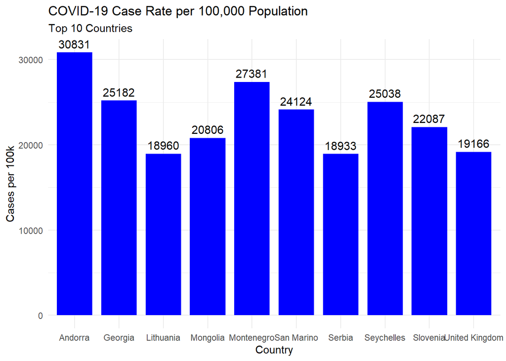

```r
#a bar graph is great to show single number comparisons across categories
case_rate_graph <- highest_country_case_rates %>%
  ggplot(
    aes(
      x = country,
      y = case_rate_per_100k
      )
    ) +
  geom_col(
    fill = "blue",
    width = 0.8
  ) +
  geom_text(
    aes(label = round(case_rate_per_100k, 0)), #round to zero decimal places
    vjust = -0.5, #positioning text above
    size = 4
  ) +
  labs(
    title = "COVID-19 Case Rate per 100,000 Population",
    subtitle = "Top 10 Countries",
    x = "Country",
    y = "Cases per 100k"
  ) +
    theme_minimal()


death_rate_graph <- highest_country_death_rates %>%
  ggplot(
    aes(
      x = country,
      y = death_rate_per_100k
      )
    ) +
  geom_col(
    fill = "black",
    width = 0.8
  ) +
  geom_text(
    aes(label = round(death_rate_per_100k, 0)), #round to zero decimal places
    vjust = -0.5, #positioning text above
    size = 4
  ) +
  labs(
    title = "COVID-19 Death Rate per 100,000 Population",
    subtitle = "Top 10 Countries",
    x = "Country",
    y = "Deaths per 100k"
  ) +
  theme_minimal()

case_rate_graph
```

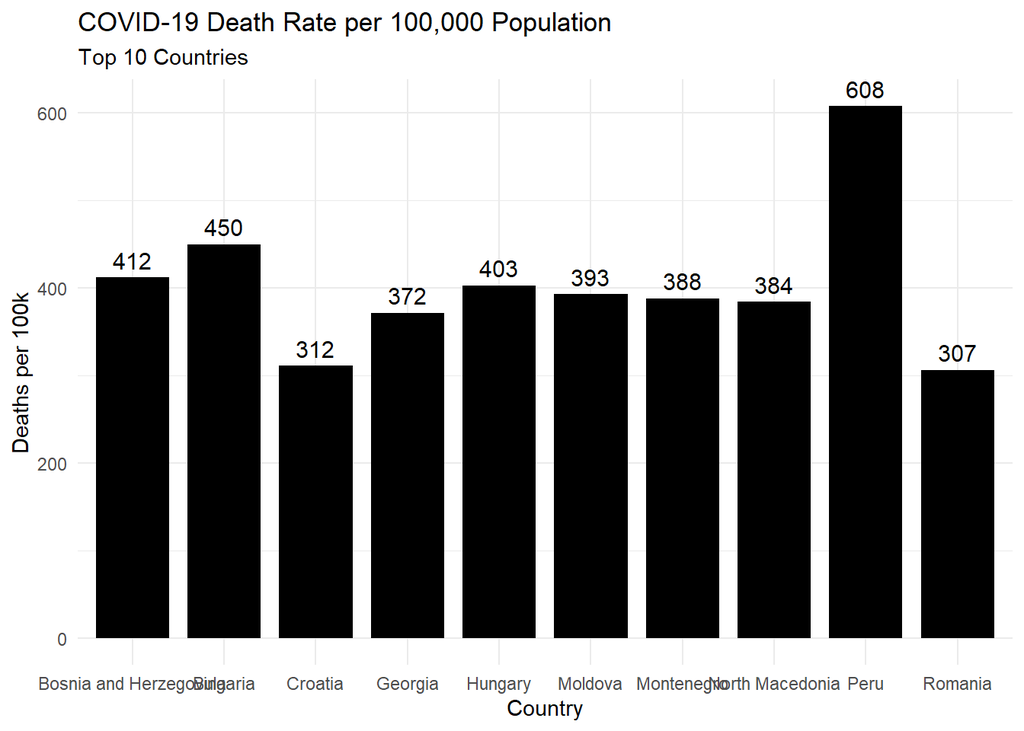

```r
death_rate_graph
```

– Communicate your methodology, results, and interpretation here – The data were collected a previously described. However, the data were filtered to the highest death rates and highest case rates, top 10 each. Perus stands out as much higher death rates than the other top 10. The case rates were much more homogenous with highest case rate being in Andorra at about 10% more than the 2nd highest country, Montenegro.

##### Question 4

Finally, select four countries from one continent and create visualizations for the daily number of confirmed cases per 100,000 and the daily number of deaths per 100,000 people between March 15, 2020, and December 31, 2021.

```r
countries_four <- c("France", "Spain", "Portugal", "Italy")

csse_global_combined_4 <- csse_global_combined %>%
  filter(
    country %in% countries_four,
    date >= as.Date("2020-03-15"),
    date <= as.Date("2021-12-31")
  ) %>%
  group_by(
    date,
    country
  ) %>%
  summarise(
    country_daily_cases = sum(cases),
    country_daily_deaths = sum(deaths),
    .groups = "drop"
  ) %>%
  left_join(
    global_population_estimates,
    by = "country"
  ) %>%
  select(
    -c("country_code", "2020")
  ) %>%
  mutate(
    country_daily_case_rate = (country_daily_cases/`2021`)*1e5,
    country_daily_death_rate = (country_daily_deaths/`2021`)*1e5
  )

csse_global_combined_4
```

| date | country | country_daily_cases | country_daily_deaths | 2021 | country_daily_case_rate | country_daily_death_rate |
| --- | --- | --- | --- | --- | --- | --- |
| 2020-03-15 | France | 4532 | 91 | 67534000 | 6.710694 | 1.347469e-01 |
| 2020-03-15 | Italy | 24747 | 1809 | 59325000 | 41.714286 | 3.049305e+00 |
| 2020-03-15 | Portugal | 245 | 0 | 10265000 | 2.386751 | 0.000000e+00 |
| 2020-03-15 | Spain | 7798 | 289 | 47336000 | 16.473720 | 6.105290e-01 |
| 2020-03-16 | France | 6683 | 149 | 67534000 | 9.895756 | 2.206296e-01 |
| 2020-03-16 | Italy | 27980 | 2158 | 59325000 | 47.163928 | 3.637590e+00 |
| 2020-03-16 | Portugal | 331 | 0 | 10265000 | 3.224549 | 0.000000e+00 |
| 2020-03-16 | Spain | 9942 | 342 | 47336000 | 21.003042 | 7.224945e-01 |
| 2020-03-17 | France | 7715 | 149 | 67534000 | 11.423875 | 2.206296e-01 |
| 2020-03-17 | Italy | 31506 | 2503 | 59325000 | 53.107459 | 4.219132e+00 |

[output cut: 2618 more lines]

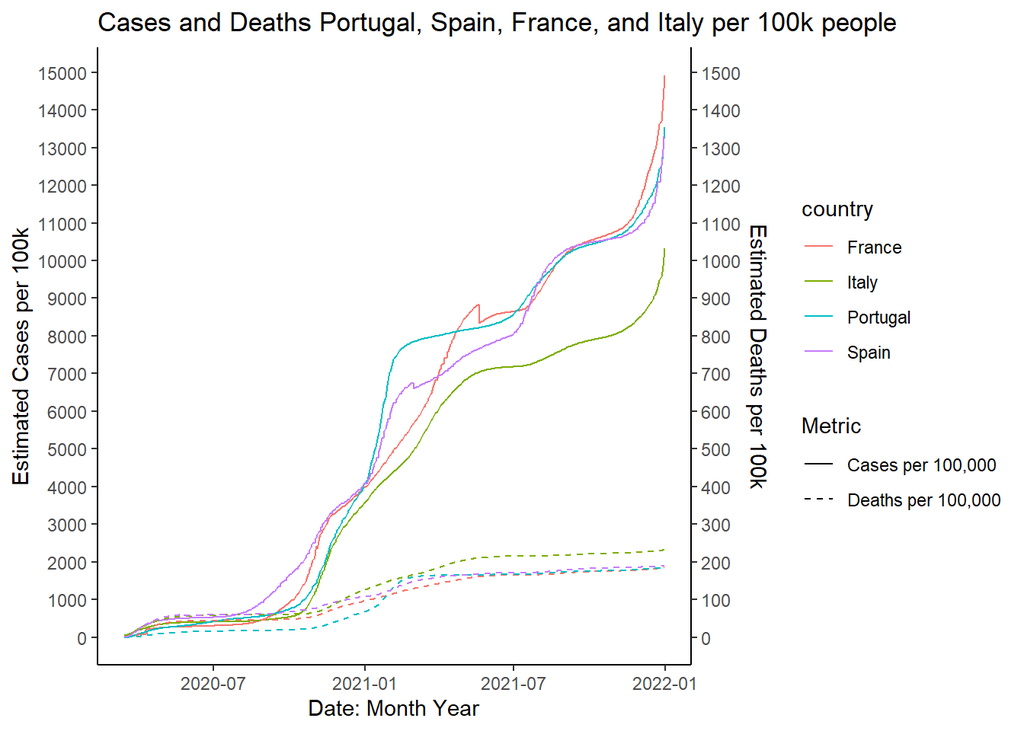

```r
scaling_factor_4 <- 10
four_country_vis <-  csse_global_combined_4 %>%
  ggplot(aes(x = date, color = country)) +
  geom_line(aes(y = (country_daily_case_rate), linetype = "Cases per 100,000")) +
  geom_line(aes(y = (country_daily_death_rate * scaling_factor_4), linetype = "Deaths per 100,000")) +
  labs(title = "Cases and Deaths Portugal, Spain, France, and Italy per 100k people",
       y = "Count",
       x = "Date: Month Year") +
  scale_y_continuous(
    breaks = seq(from = 0, to = max(csse_global_combined_4$country_daily_cases, na.rm = TRUE) + 500, by = 1000),
    name = "Estimated Cases per 100k",
    sec.axis = sec_axis(
      breaks = seq(from = 0, to = max(csse_global_combined_4$country_daily_deaths, na.rm = TRUE) + 250, by = 100),
      transform = ~ . / scaling_factor_4,
      name = "Estimated Deaths per 100k"
    )
  ) +
  scale_linetype_manual(
    values = c("Cases per 100,000" = "solid", "Deaths per 100,000" = "dashed"),
    name = "Metric"
  ) +
  theme_classic()

four_country_vis
```